# Main Analysis

Author

Jacob Simmering

```r
library(tidyverse)
library(survival)
library(tableone)
library(gtsummary)
```

# Data Loading and Processing

```r
if (Sys.info()["sysname"] == "Darwin") {
  model_data <- read_rds("/Volumes/lss_jsimmeri/als/model_data.rds")
} else {
  model_data <- read_rds("/Shared/lss_jsimmeri/als/model_data.rds")
}
```

```r
model_data <- model_data |>
  mutate(
    age = first_year - dobyr,
    female = sex == 1,
    stratum = as.numeric(as.factor(glue::glue("{first_year}-{last_year}-{dobyr}-{sex}")))
  ) |>
  mutate(any_sx = motor | bulbar,
         n_groups = motor + bulbar,
         n_bulbar = speech + swallowing,
         n_motor = strength + gait + involuntary_movement + pain + other + falls,
         n_total = speech + swallowing + strength + gait + involuntary_movement + pain + other + falls)
```

# Data Summary

First, the data summary by ALS status:

```r
all_vars <- c(
  "age", "female",
  "first_year", "last_year",
  "rate_outpatient_visits", "intensity_outpatient_visits_dx",
  "rate_inpatient_stays", "intensity_inpatient_stays_los",
  "elix_CHF", "elix_Valvular", "elix_PHTN", "elix_PVD", "elix_HTN",
  "elix_HTNcx", "elix_Paralysis", "elix_NeuroOther", "elix_Pulmonary", "elix_DM",
  "elix_DMcx", "elix_Hypothyroid", "elix_Renal", "elix_Liver", "elix_PUD",
  "elix_HIV", "elix_Lymphoma", "elix_Mets", "elix_Tumor", "elix_Rheumatic",
  "elix_Coagulopathy", "elix_Obesity", "elix_WeightLoss", "elix_FluidsLytes", "elix_BloodLoss",
  "elix_Anemia", "elix_Alcohol", "elix_Drugs", "elix_Psychoses", "elix_Depression",
  "lives_in_msa",
  "any_sx", "motor", "bulbar",
  "n_groups", "n_bulbar", "n_motor", "n_total",
  "speech", "swallowing",
  "strength", "gait", "involuntary_movement", "pain", "other", "falls")
factor_vars <- c("n_groups", "n_bulbar", "n_motor", "n_total")
nonnormal_vars <- c("age", "first_year", "last_year", "rate_outpatient_visits",
  "intensity_outpatient_visits_dx", "rate_inpatient_stays",
  "intensity_inpatient_stays_los")

CreateTableOne(
  data = model_data,
  vars = all_vars,
  factorVars = factor_vars,
  strata = c("als")
) |>
  print(nonnormal = nonnormal_vars, smd = TRUE)
```

```
                                               Stratified by als
                                                FALSE
  n                                               96126
  age (median [IQR])                              56.00 [47.00, 65.00]
  female = TRUE (%)                               54325 (56.5)
  first_year (median [IQR])                     2007.00 [2003.00, 2010.00]
  last_year (median [IQR])                      2012.00 [2008.00, 2015.00]
  rate_outpatient_visits (median [IQR])            7.10 [2.89, 14.56]
  intensity_outpatient_visits_dx (median [IQR])    1.51 [1.21, 2.03]
  rate_inpatient_stays (median [IQR])              0.00 [0.00, 0.12]
  intensity_inpatient_stays_los (median [IQR])     0.00 [0.00, 1.50]
  elix_CHF = TRUE (%)                              8899 ( 9.3)
  elix_Valvular = TRUE (%)                        12631 (13.1)
  elix_PHTN = TRUE (%)                             3107 ( 3.2)
  elix_PVD = TRUE (%)                             12089 (12.6)
  elix_HTN = TRUE (%)                             48410 (50.4)
  elix_HTNcx = TRUE (%)                           11065 (11.5)
  elix_Paralysis = TRUE (%)                        2065 ( 2.1)
  elix_NeuroOther = TRUE (%)                       9944 (10.3)
  elix_Pulmonary = TRUE (%)                       21899 (22.8)
  elix_DM = TRUE (%)                              20001 (20.8)
  elix_DMcx = TRUE (%)                             8413 ( 8.8)
  elix_Hypothyroid = TRUE (%)                     13543 (14.1)
  elix_Renal = TRUE (%)                            6213 ( 6.5)
  elix_Liver = TRUE (%)                            4626 ( 4.8)
  elix_PUD = TRUE (%)                               491 ( 0.5)
  elix_HIV = TRUE (%)                               188 ( 0.2)
  elix_Lymphoma = TRUE (%)                         1326 ( 1.4)
  elix_Mets = TRUE (%)                             3508 ( 3.6)
  elix_Tumor = TRUE (%)                           12044 (12.5)
  elix_Rheumatic = TRUE (%)                        5852 ( 6.1)
  elix_Coagulopathy = TRUE (%)                     3999 ( 4.2)
  elix_Obesity = TRUE (%)                         11063 (11.5)
  elix_WeightLoss = TRUE (%)                       5374 ( 5.6)
  elix_FluidsLytes = TRUE (%)                     13387 (13.9)
  elix_BloodLoss = TRUE (%)                        2005 ( 2.1)
  elix_Anemia = TRUE (%)                          16207 (16.9)
  elix_Alcohol = TRUE (%)                          2022 ( 2.1)
  elix_Drugs = TRUE (%)                            1292 ( 1.3)
  elix_Psychoses = TRUE (%)                        7433 ( 7.7)
```

[output cut: 182 more lines]

```
     2
     3
     4
     5
     6
     7
     8
  speech = TRUE (%)                             <0.001          0.576
  swallowing = TRUE (%)                         <0.001          0.098
  strength = TRUE (%)                           <0.001          0.802
  gait = TRUE (%)                               <0.001          0.559
  involuntary_movement = TRUE (%)               <0.001          0.502
  pain = TRUE (%)                               <0.001          0.292
  other = TRUE (%)                              <0.001          0.746
  falls = TRUE (%)                              <0.001          0.162
```

And then by ALS and whether they live in an MSA:

```r
CreateTableOne(
  data = model_data,
  vars = all_vars,
  factorVars = factor_vars,
  strata = c("als", "lives_in_msa")
) |>
  print(nonnormal = nonnormal_vars, smd = TRUE)
```

```
                                               Stratified by als:lives_in_msa
                                                FALSE:FALSE
  n                                               14881
  age (median [IQR])                              57.00 [48.00, 65.00]
  female = TRUE (%)                                8636 (58.0)
  first_year (median [IQR])                     2007.00 [2002.00, 2010.00]
  last_year (median [IQR])                      2011.00 [2008.00, 2014.00]
  rate_outpatient_visits (median [IQR])            6.86 [2.83, 13.91]
  intensity_outpatient_visits_dx (median [IQR])    1.51 [1.22, 2.04]
  rate_inpatient_stays (median [IQR])              0.00 [0.00, 0.14]
  intensity_inpatient_stays_los (median [IQR])     0.00 [0.00, 1.50]
  elix_CHF = TRUE (%)                              1310 ( 8.8)
  elix_Valvular = TRUE (%)                         1660 (11.2)
  elix_PHTN = TRUE (%)                              439 ( 3.0)
  elix_PVD = TRUE (%)                              1724 (11.6)
  elix_HTN = TRUE (%)                              7787 (52.3)
  elix_HTNcx = TRUE (%)                            1433 ( 9.6)
  elix_Paralysis = TRUE (%)                         305 ( 2.0)
  elix_NeuroOther = TRUE (%)                       1432 ( 9.6)
  elix_Pulmonary = TRUE (%)                        3524 (23.7)
  elix_DM = TRUE (%)                               3025 (20.3)
  elix_DMcx = TRUE (%)                             1125 ( 7.6)
  elix_Hypothyroid = TRUE (%)                      1987 (13.4)
  elix_Renal = TRUE (%)                             822 ( 5.5)
  elix_Liver = TRUE (%)                             621 ( 4.2)
  elix_PUD = TRUE (%)                                65 ( 0.4)
  elix_HIV = TRUE (%)                                 8 ( 0.1)
  elix_Lymphoma = TRUE (%)                          163 ( 1.1)
  elix_Mets = TRUE (%)                              534 ( 3.6)
  elix_Tumor = TRUE (%)                            1775 (11.9)
  elix_Rheumatic = TRUE (%)                         891 ( 6.0)
  elix_Coagulopathy = TRUE (%)                      557 ( 3.7)
  elix_Obesity = TRUE (%)                          1613 (10.8)
  elix_WeightLoss = TRUE (%)                        818 ( 5.5)
  elix_FluidsLytes = TRUE (%)                      1977 (13.3)
  elix_BloodLoss = TRUE (%)                         276 ( 1.9)
  elix_Anemia = TRUE (%)                           2094 (14.1)
  elix_Alcohol = TRUE (%)                           280 ( 1.9)
  elix_Drugs = TRUE (%)                             173 ( 1.2)
  elix_Psychoses = TRUE (%)                         954 ( 6.4)
```

[output cut: 340 more lines]

```
     2
     3
     4
     5
     6
     7
     8
  speech = TRUE (%)                             <0.001          0.413
  swallowing = TRUE (%)                         <0.001          0.067
  strength = TRUE (%)                           <0.001          0.577
  gait = TRUE (%)                               <0.001          0.395
  involuntary_movement = TRUE (%)               <0.001          0.340
  pain = TRUE (%)                               <0.001          0.210
  other = TRUE (%)                              <0.001          0.540
  falls = TRUE (%)                              <0.001          0.110
```

# Define Models

First, does having any of these codes increase the odds of getting an ALS diagnosis?

```r
any_fml_unadj <- als ~ any_sx * lives_in_msa + strata(stratum)

any_fml_fulladj <- als ~ rate_outpatient_visits + intensity_outpatient_visits_dx +
                   rate_inpatient_stays + intensity_inpatient_stays_los +
                   elix_CHF + elix_Valvular + elix_PHTN + elix_PVD + elix_HTN +
                   elix_HTNcx + elix_Paralysis + elix_NeuroOther + elix_Pulmonary + elix_DM +
                   elix_DMcx + elix_Hypothyroid + elix_Renal + elix_Liver + elix_PUD +
                   elix_HIV + elix_Lymphoma + elix_Mets + elix_Tumor + elix_Rheumatic +
                   elix_Coagulopathy + elix_Obesity + elix_WeightLoss + elix_FluidsLytes + elix_BloodLoss +
                   elix_Anemia + elix_Alcohol + elix_Drugs + elix_Psychoses + elix_Depression +
                   any_sx * lives_in_msa + strata(stratum)
```

Second, what is the independent effect of bulbar symptoms?

```r
any_bulbar_unadj <- als ~ bulbar * lives_in_msa + strata(stratum)

any_bulbar_fulladj <- als ~ rate_outpatient_visits + intensity_outpatient_visits_dx +
                   rate_inpatient_stays + intensity_inpatient_stays_los +
                   elix_CHF + elix_Valvular + elix_PHTN + elix_PVD + elix_HTN +
                   elix_HTNcx + elix_Paralysis + elix_NeuroOther + elix_Pulmonary + elix_DM +
                   elix_DMcx + elix_Hypothyroid + elix_Renal + elix_Liver + elix_PUD +
                   elix_HIV + elix_Lymphoma + elix_Mets + elix_Tumor + elix_Rheumatic +
                   elix_Coagulopathy + elix_Obesity + elix_WeightLoss + elix_FluidsLytes + elix_BloodLoss +
                   elix_Anemia + elix_Alcohol + elix_Drugs + elix_Psychoses + elix_Depression +
                   bulbar * lives_in_msa + strata(stratum)
```

Third, what is the independent effect of motor symptoms?

```r
any_motor_unadj <- als ~ motor * lives_in_msa + strata(stratum)

any_motor_fulladj <- als ~ rate_outpatient_visits + intensity_outpatient_visits_dx +
                   rate_inpatient_stays + intensity_inpatient_stays_los +
                   elix_CHF + elix_Valvular + elix_PHTN + elix_PVD + elix_HTN +
                   elix_HTNcx + elix_Paralysis + elix_NeuroOther + elix_Pulmonary + elix_DM +
                   elix_DMcx + elix_Hypothyroid + elix_Renal + elix_Liver + elix_PUD +
                   elix_HIV + elix_Lymphoma + elix_Mets + elix_Tumor + elix_Rheumatic +
                   elix_Coagulopathy + elix_Obesity + elix_WeightLoss + elix_FluidsLytes + elix_BloodLoss +
                   elix_Anemia + elix_Alcohol + elix_Drugs + elix_Psychoses + elix_Depression +
                   motor * lives_in_msa + strata(stratum)
```

Fourth, what is the effect of symptoms from 0, 1, or 2 affects systems?

```r
number_origin_unadj <- als ~ as.factor(I(bulbar + motor)) * lives_in_msa + strata(stratum)

number_origin_fulladj <- als ~ rate_outpatient_visits + intensity_outpatient_visits_dx +
                   rate_inpatient_stays + intensity_inpatient_stays_los +
                   elix_CHF + elix_Valvular + elix_PHTN + elix_PVD + elix_HTN +
                   elix_HTNcx + elix_Paralysis + elix_NeuroOther + elix_Pulmonary + elix_DM +
                   elix_DMcx + elix_Hypothyroid + elix_Renal + elix_Liver + elix_PUD +
                   elix_HIV + elix_Lymphoma + elix_Mets + elix_Tumor + elix_Rheumatic +
                   elix_Coagulopathy + elix_Obesity + elix_WeightLoss + elix_FluidsLytes + elix_BloodLoss +
                   elix_Anemia + elix_Alcohol + elix_Drugs + elix_Psychoses + elix_Depression +
                   as.factor(I(bulbar + motor)) * lives_in_msa + strata(stratum)
```

Fifth, what is the effect of the symptom sub-class? This is actually many models…

```r
speech_fml_unadj <- als ~ speech * lives_in_msa + strata(stratum)

speech_fml_fulladj <- als ~ rate_outpatient_visits + intensity_outpatient_visits_dx +
                   rate_inpatient_stays + intensity_inpatient_stays_los +
                   elix_CHF + elix_Valvular + elix_PHTN + elix_PVD + elix_HTN +
                   elix_HTNcx + elix_Paralysis + elix_NeuroOther + elix_Pulmonary + elix_DM +
                   elix_DMcx + elix_Hypothyroid + elix_Renal + elix_Liver + elix_PUD +
                   elix_HIV + elix_Lymphoma + elix_Mets + elix_Tumor + elix_Rheumatic +
                   elix_Coagulopathy + elix_Obesity + elix_WeightLoss + elix_FluidsLytes + elix_BloodLoss +
                   elix_Anemia + elix_Alcohol + elix_Drugs + elix_Psychoses + elix_Depression +
                   speech * lives_in_msa + strata(stratum)

swallowing_fml_unadj <- als ~ swallowing * lives_in_msa + strata(stratum)

swallowing_fml_fulladj <- als ~ rate_outpatient_visits + intensity_outpatient_visits_dx +
                   rate_inpatient_stays + intensity_inpatient_stays_los +
                   elix_CHF + elix_Valvular + elix_PHTN + elix_PVD + elix_HTN +
                   elix_HTNcx + elix_Paralysis + elix_NeuroOther + elix_Pulmonary + elix_DM +
                   elix_DMcx + elix_Hypothyroid + elix_Renal + elix_Liver + elix_PUD +
                   elix_HIV + elix_Lymphoma + elix_Mets + elix_Tumor + elix_Rheumatic +
                   elix_Coagulopathy + elix_Obesity + elix_WeightLoss + elix_FluidsLytes + elix_BloodLoss +
                   elix_Anemia + elix_Alcohol + elix_Drugs + elix_Psychoses + elix_Depression +
                   swallowing * lives_in_msa + strata(stratum)

strength_fml_unadj <- als ~ strength * lives_in_msa + strata(stratum)

strength_fml_fulladj <- als ~ rate_outpatient_visits + intensity_outpatient_visits_dx +
                   rate_inpatient_stays + intensity_inpatient_stays_los +
                   elix_CHF + elix_Valvular + elix_PHTN + elix_PVD + elix_HTN +
                   elix_HTNcx + elix_Paralysis + elix_NeuroOther + elix_Pulmonary + elix_DM +
                   elix_DMcx + elix_Hypothyroid + elix_Renal + elix_Liver + elix_PUD +
                   elix_HIV + elix_Lymphoma + elix_Mets + elix_Tumor + elix_Rheumatic +
                   elix_Coagulopathy + elix_Obesity + elix_WeightLoss + elix_FluidsLytes + elix_BloodLoss +
                   elix_Anemia + elix_Alcohol + elix_Drugs + elix_Psychoses + elix_Depression +
                   strength * lives_in_msa + strata(stratum)

gait_fml_unadj <- als ~ gait * lives_in_msa + strata(stratum)

gait_fml_fulladj <- als ~ rate_outpatient_visits + intensity_outpatient_visits_dx +
                   rate_inpatient_stays + intensity_inpatient_stays_los +
                   elix_CHF + elix_Valvular + elix_PHTN + elix_PVD + elix_HTN +
                   elix_HTNcx + elix_Paralysis + elix_NeuroOther + elix_Pulmonary + elix_DM +
                   elix_DMcx + elix_Hypothyroid + elix_Renal + elix_Liver + elix_PUD +
                   elix_HIV + elix_Lymphoma + elix_Mets + elix_Tumor + elix_Rheumatic +
                   elix_Coagulopathy + elix_Obesity + elix_WeightLoss + elix_FluidsLytes + elix_BloodLoss +
                   elix_Anemia + elix_Alcohol + elix_Drugs + elix_Psychoses + elix_Depression +
                   gait * lives_in_msa + strata(stratum)

involuntary_movement_fml_unadj <- als ~ involuntary_movement * lives_in_msa + strata(stratum)

involuntary_movement_fml_fulladj <- als ~ rate_outpatient_visits + intensity_outpatient_visits_dx +
                   rate_inpatient_stays + intensity_inpatient_stays_los +
                   elix_CHF + elix_Valvular + elix_PHTN + elix_PVD + elix_HTN +
                   elix_HTNcx + elix_Paralysis + elix_NeuroOther + elix_Pulmonary + elix_DM +
                   elix_DMcx + elix_Hypothyroid + elix_Renal + elix_Liver + elix_PUD +
                   elix_HIV + elix_Lymphoma + elix_Mets + elix_Tumor + elix_Rheumatic +
                   elix_Coagulopathy + elix_Obesity + elix_WeightLoss + elix_FluidsLytes + elix_BloodLoss +
                   elix_Anemia + elix_Alcohol + elix_Drugs + elix_Psychoses + elix_Depression +
                   involuntary_movement * lives_in_msa + strata(stratum)

pain_fml_unadj <- als ~ pain * lives_in_msa + strata(stratum)

pain_fml_fulladj <- als ~ rate_outpatient_visits + intensity_outpatient_visits_dx +
                   rate_inpatient_stays + intensity_inpatient_stays_los +
                   elix_CHF + elix_Valvular + elix_PHTN + elix_PVD + elix_HTN +
                   elix_HTNcx + elix_Paralysis + elix_NeuroOther + elix_Pulmonary + elix_DM +
                   elix_DMcx + elix_Hypothyroid + elix_Renal + elix_Liver + elix_PUD +
                   elix_HIV + elix_Lymphoma + elix_Mets + elix_Tumor + elix_Rheumatic +
                   elix_Coagulopathy + elix_Obesity + elix_WeightLoss + elix_FluidsLytes + elix_BloodLoss +
                   elix_Anemia + elix_Alcohol + elix_Drugs + elix_Psychoses + elix_Depression +
                   pain * lives_in_msa + strata(stratum)

other_fml_unadj <- als ~ other * lives_in_msa + strata(stratum)

other_fml_fulladj <- als ~ rate_outpatient_visits + intensity_outpatient_visits_dx +
                   rate_inpatient_stays + intensity_inpatient_stays_los +
                   elix_CHF + elix_Valvular + elix_PHTN + elix_PVD + elix_HTN +
                   elix_HTNcx + elix_Paralysis + elix_NeuroOther + elix_Pulmonary + elix_DM +
                   elix_DMcx + elix_Hypothyroid + elix_Renal + elix_Liver + elix_PUD +
                   elix_HIV + elix_Lymphoma + elix_Mets + elix_Tumor + elix_Rheumatic +
                   elix_Coagulopathy + elix_Obesity + elix_WeightLoss + elix_FluidsLytes + elix_BloodLoss +
                   elix_Anemia + elix_Alcohol + elix_Drugs + elix_Psychoses + elix_Depression +
                   other * lives_in_msa + strata(stratum)

falls_fml_unadj <- als ~ falls * lives_in_msa + strata(stratum)

falls_fml_fulladj <- als ~ rate_outpatient_visits + intensity_outpatient_visits_dx +
                   rate_inpatient_stays + intensity_inpatient_stays_los +
                   elix_CHF + elix_Valvular + elix_PHTN + elix_PVD + elix_HTN +
                   elix_HTNcx + elix_Paralysis + elix_NeuroOther + elix_Pulmonary + elix_DM +
                   elix_DMcx + elix_Hypothyroid + elix_Renal + elix_Liver + elix_PUD +
                   elix_HIV + elix_Lymphoma + elix_Mets + elix_Tumor + elix_Rheumatic +
                   elix_Coagulopathy + elix_Obesity + elix_WeightLoss + elix_FluidsLytes + elix_BloodLoss +
                   elix_Anemia + elix_Alcohol + elix_Drugs + elix_Psychoses + elix_Depression +
                   falls * lives_in_msa + strata(stratum)
```

Sixth, does the risk increase with each additional symptom?

```r
number_fml_unadj <- als ~ as.factor(n_total) * lives_in_msa + strata(stratum)

number_fml_fulladj <- als ~ rate_outpatient_visits + intensity_outpatient_visits_dx +
                   rate_inpatient_stays + intensity_inpatient_stays_los +
                   elix_CHF + elix_Valvular + elix_PHTN + elix_PVD + elix_HTN +
                   elix_HTNcx + elix_Paralysis + elix_NeuroOther + elix_Pulmonary + elix_DM +
                   elix_DMcx + elix_Hypothyroid + elix_Renal + elix_Liver + elix_PUD +
                   elix_HIV + elix_Lymphoma + elix_Mets + elix_Tumor + elix_Rheumatic +
                   elix_Coagulopathy + elix_Obesity + elix_WeightLoss + elix_FluidsLytes + elix_BloodLoss +
                   elix_Anemia + elix_Alcohol + elix_Drugs + elix_Psychoses + elix_Depression +
                   as.factor(n_total) * lives_in_msa + strata(stratum)
```

Quick note: all of these models omit year, age, and sex. This is because the data are matched on age, sex, and enrollment start/end dates. Including the strata accounts for these factors while also properly clustering the errors.

# Estimation

## Does Having Any Code Increase the Risk?

Without adjustment:

```r
clogit(
  any_fml_unadj,
  model_data
) |>
  broom::tidy(exponentiate = TRUE, conf.int = TRUE) |>
  select(term, estimate, conf.low, conf.high) |>
  knitr::kable(digits = 2)
```

| term | estimate | conf.low | conf.high |
| --- | --- | --- | --- |
| any_sxTRUE | 7.44 | 6.62 | 8.36 |
| lives_in_msaTRUE | 1.43 | 1.28 | 1.60 |
| any_sxTRUE:lives_in_msaTRUE | 0.84 | 0.75 | 0.96 |

The odds are increased following one or more symptom (OR = 7.44), for those living in MSAs (OR = 1.43), but there is a multiplicative decrease in odds for ALS for those with symptoms living in an MSA (OR = 0.84). The odds are still increased (OR = $0.84 * 7.44 = 6.25$) but less than for those who do not live in MSAs.

After adjustment, the story stays the same:

```r
clogit(
  any_fml_fulladj,
  model_data
) |>
  broom::tidy(exponentiate = TRUE, conf.int = TRUE) |>
  select(term, estimate, conf.low, conf.high) |>
  knitr::kable(digits = 2)
```

| term | estimate | conf.low | conf.high |
| --- | --- | --- | --- |
| rate_outpatient_visits | 1.02 | 1.02 | 1.03 |
| intensity_outpatient_visits_dx | 1.15 | 1.10 | 1.19 |
| rate_inpatient_stays | 0.78 | 0.74 | 0.82 |
| intensity_inpatient_stays_los | 0.99 | 0.99 | 1.00 |
| elix_CHFTRUE | 0.64 | 0.59 | 0.69 |
| elix_ValvularTRUE | 0.97 | 0.92 | 1.03 |
| elix_PHTNTRUE | 0.99 | 0.90 | 1.09 |
| elix_PVDTRUE | 0.91 | 0.86 | 0.96 |
| elix_HTNTRUE | 0.98 | 0.94 | 1.02 |
| elix_HTNcxTRUE | 0.91 | 0.85 | 0.97 |
| elix_ParalysisTRUE | 3.00 | 2.78 | 3.23 |
| elix_NeuroOtherTRUE | 5.21 | 4.98 | 5.45 |
| elix_PulmonaryTRUE | 0.95 | 0.91 | 1.00 |
| elix_DMTRUE | 0.86 | 0.82 | 0.91 |
| elix_DMcxTRUE | 0.80 | 0.74 | 0.86 |
| elix_HypothyroidTRUE | 1.11 | 1.05 | 1.16 |
| elix_RenalTRUE | 0.60 | 0.55 | 0.65 |
| elix_LiverTRUE | 0.94 | 0.87 | 1.02 |
| elix_PUDTRUE | 1.00 | 0.80 | 1.25 |
| elix_HIVTRUE | 0.98 | 0.68 | 1.40 |
| elix_LymphomaTRUE | 1.20 | 1.05 | 1.38 |
| elix_MetsTRUE | 0.33 | 0.29 | 0.38 |
| elix_TumorTRUE | 0.86 | 0.81 | 0.92 |
| elix_RheumaticTRUE | 1.24 | 1.17 | 1.32 |
| elix_CoagulopathyTRUE | 0.85 | 0.78 | 0.93 |
| elix_ObesityTRUE | 0.83 | 0.78 | 0.88 |
| elix_WeightLossTRUE | 1.69 | 1.59 | 1.81 |
| elix_FluidsLytesTRUE | 0.80 | 0.75 | 0.85 |
| elix_BloodLossTRUE | 0.70 | 0.61 | 0.79 |
| elix_AnemiaTRUE | 1.05 | 0.99 | 1.10 |
| elix_AlcoholTRUE | 0.83 | 0.74 | 0.93 |
| elix_DrugsTRUE | 0.82 | 0.72 | 0.94 |
| elix_PsychosesTRUE | 0.82 | 0.77 | 0.87 |
| elix_DepressionTRUE | 0.97 | 0.92 | 1.02 |
| any_sxTRUE | 4.92 | 4.36 | 5.56 |
| lives_in_msaTRUE | 1.44 | 1.28 | 1.61 |
| any_sxTRUE:lives_in_msaTRUE | 0.83 | 0.73 | 0.94 |

## Are There Differences Between Bulbar and Motor Symptoms?

Bulbar symptoms alone increases the odds before adjustment:

```r
clogit(
  any_bulbar_unadj,
  model_data
) |>
  broom::tidy(exponentiate = TRUE, conf.int = TRUE) |>
  select(term, estimate, conf.low, conf.high) |>
  knitr::kable(digits = 2)
```

| term | estimate | conf.low | conf.high |
| --- | --- | --- | --- |
| bulbarTRUE | 6.39 | 5.74 | 7.11 |
| lives_in_msaTRUE | 1.30 | 1.23 | 1.37 |
| bulbarTRUE:lives_in_msaTRUE | 0.84 | 0.75 | 0.94 |

And unsurprisingly adjustment does not change the story:

```r
clogit(
  any_bulbar_fulladj,
  model_data
) |>
  broom::tidy(exponentiate = TRUE, conf.int = TRUE) |>
  select(term, estimate, conf.low, conf.high) |>
  knitr::kable(digits = 2)
```

| term | estimate | conf.low | conf.high |
| --- | --- | --- | --- |
| rate_outpatient_visits | 1.03 | 1.03 | 1.03 |
| intensity_outpatient_visits_dx | 1.29 | 1.25 | 1.34 |
| rate_inpatient_stays | 0.78 | 0.74 | 0.83 |
| intensity_inpatient_stays_los | 0.99 | 0.99 | 1.00 |
| elix_CHFTRUE | 0.60 | 0.55 | 0.65 |
| elix_ValvularTRUE | 0.94 | 0.89 | 1.00 |
| elix_PHTNTRUE | 0.94 | 0.85 | 1.04 |
| elix_PVDTRUE | 0.92 | 0.87 | 0.98 |
| elix_HTNTRUE | 1.03 | 0.99 | 1.08 |
| elix_HTNcxTRUE | 0.88 | 0.82 | 0.94 |
| elix_ParalysisTRUE | 3.00 | 2.77 | 3.24 |
| elix_NeuroOtherTRUE | 5.23 | 4.99 | 5.47 |
| elix_PulmonaryTRUE | 0.93 | 0.89 | 0.97 |
| elix_DMTRUE | 0.85 | 0.80 | 0.90 |
| elix_DMcxTRUE | 0.80 | 0.74 | 0.87 |
| elix_HypothyroidTRUE | 1.10 | 1.04 | 1.15 |
| elix_RenalTRUE | 0.55 | 0.50 | 0.60 |
| elix_LiverTRUE | 0.95 | 0.88 | 1.03 |
| elix_PUDTRUE | 0.92 | 0.72 | 1.16 |
| elix_HIVTRUE | 0.85 | 0.59 | 1.22 |
| elix_LymphomaTRUE | 1.15 | 1.00 | 1.32 |
| elix_MetsTRUE | 0.30 | 0.26 | 0.34 |
| elix_TumorTRUE | 0.84 | 0.79 | 0.89 |
| elix_RheumaticTRUE | 1.36 | 1.27 | 1.45 |
| elix_CoagulopathyTRUE | 0.83 | 0.76 | 0.91 |
| elix_ObesityTRUE | 0.84 | 0.79 | 0.90 |
| elix_WeightLossTRUE | 1.57 | 1.47 | 1.67 |
| elix_FluidsLytesTRUE | 0.77 | 0.73 | 0.82 |
| elix_BloodLossTRUE | 0.65 | 0.57 | 0.74 |
| elix_AnemiaTRUE | 1.05 | 1.00 | 1.11 |
| elix_AlcoholTRUE | 0.88 | 0.78 | 0.99 |
| elix_DrugsTRUE | 0.83 | 0.72 | 0.96 |
| elix_PsychosesTRUE | 0.79 | 0.74 | 0.84 |
| elix_DepressionTRUE | 0.96 | 0.91 | 1.02 |
| bulbarTRUE | 3.80 | 3.37 | 4.29 |
| lives_in_msaTRUE | 1.27 | 1.20 | 1.35 |
| bulbarTRUE:lives_in_msaTRUE | 0.84 | 0.74 | 0.95 |

The same is true of motor symptoms

```r
clogit(
  any_motor_unadj,
  model_data
) |>
  broom::tidy(exponentiate = TRUE, conf.int = TRUE) |>
  select(term, estimate, conf.low, conf.high) |>
  knitr::kable(digits = 2)
```

| term | estimate | conf.low | conf.high |
| --- | --- | --- | --- |
| motorTRUE | 5.64 | 5.07 | 6.27 |
| lives_in_msaTRUE | 1.42 | 1.29 | 1.57 |
| motorTRUE:lives_in_msaTRUE | 0.84 | 0.75 | 0.94 |

and with adjustment:

```r
clogit(
  any_motor_fulladj,
  model_data
) |>
  broom::tidy(exponentiate = TRUE, conf.int = TRUE) |>
  select(term, estimate, conf.low, conf.high) |>
  knitr::kable(digits = 2)
```

| term | estimate | conf.low | conf.high |
| --- | --- | --- | --- |
| rate_outpatient_visits | 1.03 | 1.02 | 1.03 |
| intensity_outpatient_visits_dx | 1.19 | 1.15 | 1.23 |
| rate_inpatient_stays | 0.78 | 0.74 | 0.82 |
| intensity_inpatient_stays_los | 1.00 | 0.99 | 1.00 |
| elix_CHFTRUE | 0.63 | 0.58 | 0.68 |
| elix_ValvularTRUE | 0.97 | 0.92 | 1.02 |
| elix_PHTNTRUE | 0.98 | 0.89 | 1.08 |
| elix_PVDTRUE | 0.91 | 0.86 | 0.96 |
| elix_HTNTRUE | 0.98 | 0.94 | 1.02 |
| elix_HTNcxTRUE | 0.91 | 0.85 | 0.96 |
| elix_ParalysisTRUE | 3.03 | 2.81 | 3.27 |
| elix_NeuroOtherTRUE | 5.42 | 5.18 | 5.67 |
| elix_PulmonaryTRUE | 0.97 | 0.93 | 1.01 |
| elix_DMTRUE | 0.86 | 0.81 | 0.90 |
| elix_DMcxTRUE | 0.79 | 0.73 | 0.85 |
| elix_HypothyroidTRUE | 1.12 | 1.06 | 1.17 |
| elix_RenalTRUE | 0.59 | 0.54 | 0.64 |
| elix_LiverTRUE | 0.94 | 0.87 | 1.02 |
| elix_PUDTRUE | 1.02 | 0.82 | 1.28 |
| elix_HIVTRUE | 0.99 | 0.69 | 1.41 |
| elix_LymphomaTRUE | 1.19 | 1.04 | 1.36 |
| elix_MetsTRUE | 0.33 | 0.29 | 0.37 |
| elix_TumorTRUE | 0.86 | 0.81 | 0.91 |
| elix_RheumaticTRUE | 1.25 | 1.17 | 1.33 |
| elix_CoagulopathyTRUE | 0.84 | 0.77 | 0.92 |
| elix_ObesityTRUE | 0.83 | 0.78 | 0.88 |
| elix_WeightLossTRUE | 1.73 | 1.62 | 1.84 |
| elix_FluidsLytesTRUE | 0.80 | 0.75 | 0.84 |
| elix_BloodLossTRUE | 0.69 | 0.61 | 0.79 |
| elix_AnemiaTRUE | 1.04 | 0.99 | 1.09 |
| elix_AlcoholTRUE | 0.83 | 0.74 | 0.94 |
| elix_DrugsTRUE | 0.81 | 0.71 | 0.93 |
| elix_PsychosesTRUE | 0.81 | 0.76 | 0.86 |
| elix_DepressionTRUE | 0.97 | 0.92 | 1.02 |
| motorTRUE | 3.75 | 3.35 | 4.19 |
| lives_in_msaTRUE | 1.43 | 1.29 | 1.58 |
| motorTRUE:lives_in_msaTRUE | 0.82 | 0.73 | 0.92 |

## Does the Risk Increase With Symptoms From Different Origins?

Without adjustment:

```r
clogit(
  number_origin_unadj,
  model_data
) |>
  broom::tidy(exponentiate = TRUE, conf.int = TRUE) |>
  select(term, estimate, conf.low, conf.high) |>
  knitr::kable(digits = 2)
```

| term | estimate | conf.low | conf.high |
| --- | --- | --- | --- |
| as.factor(I(bulbar + motor))1 | 5.98 | 5.30 | 6.74 |
| as.factor(I(bulbar + motor))2 | 26.38 | 22.68 | 30.67 |
| lives_in_msaTRUE | 1.45 | 1.30 | 1.62 |
| as.factor(I(bulbar + motor))1:lives_in_msaTRUE | 0.88 | 0.78 | 1.00 |
| as.factor(I(bulbar + motor))2:lives_in_msaTRUE | 0.71 | 0.61 | 0.84 |

And with adjustment

```r
clogit(
  number_origin_fulladj,
  model_data
) |>
  broom::tidy(exponentiate = TRUE, conf.int = TRUE) |>
  select(term, estimate, conf.low, conf.high) |>
  knitr::kable(digits = 2)
```

| term | estimate | conf.low | conf.high |
| --- | --- | --- | --- |
| rate_outpatient_visits | 1.02 | 1.02 | 1.02 |
| intensity_outpatient_visits_dx | 1.13 | 1.09 | 1.17 |
| rate_inpatient_stays | 0.79 | 0.74 | 0.84 |
| intensity_inpatient_stays_los | 0.99 | 0.99 | 1.00 |
| elix_CHFTRUE | 0.63 | 0.59 | 0.68 |
| elix_ValvularTRUE | 0.95 | 0.90 | 1.01 |
| elix_PHTNTRUE | 0.98 | 0.88 | 1.08 |
| elix_PVDTRUE | 0.89 | 0.84 | 0.95 |
| elix_HTNTRUE | 0.98 | 0.94 | 1.02 |
| elix_HTNcxTRUE | 0.90 | 0.84 | 0.96 |
| elix_ParalysisTRUE | 2.77 | 2.56 | 2.99 |
| elix_NeuroOtherTRUE | 4.75 | 4.54 | 4.97 |
| elix_PulmonaryTRUE | 0.92 | 0.88 | 0.96 |
| elix_DMTRUE | 0.86 | 0.81 | 0.91 |
| elix_DMcxTRUE | 0.80 | 0.74 | 0.87 |
| elix_HypothyroidTRUE | 1.09 | 1.04 | 1.14 |
| elix_RenalTRUE | 0.60 | 0.55 | 0.66 |
| elix_LiverTRUE | 0.94 | 0.87 | 1.02 |
| elix_PUDTRUE | 0.95 | 0.75 | 1.20 |
| elix_HIVTRUE | 1.02 | 0.70 | 1.46 |
| elix_LymphomaTRUE | 1.19 | 1.04 | 1.37 |
| elix_MetsTRUE | 0.33 | 0.29 | 0.38 |
| elix_TumorTRUE | 0.86 | 0.80 | 0.91 |
| elix_RheumaticTRUE | 1.22 | 1.15 | 1.30 |
| elix_CoagulopathyTRUE | 0.85 | 0.78 | 0.93 |
| elix_ObesityTRUE | 0.81 | 0.76 | 0.86 |
| elix_WeightLossTRUE | 1.57 | 1.47 | 1.68 |
| elix_FluidsLytesTRUE | 0.78 | 0.74 | 0.83 |
| elix_BloodLossTRUE | 0.68 | 0.60 | 0.78 |
| elix_AnemiaTRUE | 1.05 | 0.99 | 1.10 |
| elix_AlcoholTRUE | 0.85 | 0.75 | 0.96 |
| elix_DrugsTRUE | 0.84 | 0.73 | 0.97 |
| elix_PsychosesTRUE | 0.81 | 0.76 | 0.86 |
| elix_DepressionTRUE | 0.94 | 0.89 | 0.99 |
| as.factor(I(bulbar + motor))1 | 4.37 | 3.85 | 4.95 |
| as.factor(I(bulbar + motor))2 | 13.11 | 11.14 | 15.43 |
| lives_in_msaTRUE | 1.44 | 1.29 | 1.62 |
| as.factor(I(bulbar + motor))1:lives_in_msaTRUE | 0.87 | 0.76 | 0.99 |
| as.factor(I(bulbar + motor))2:lives_in_msaTRUE | 0.70 | 0.59 | 0.83 |

## By Symptom

### Bulbar Symptoms

#### Speech Problems

```r
speech_unadjusted <- clogit(
  speech_fml_unadj,
  model_data
)

speech_unadjusted |>
  broom::tidy(exponentiate = TRUE, conf.int = TRUE) |>
  select(term, estimate, conf.low, conf.high) |>
  knitr::kable(digits = 2)
```

| term | estimate | conf.low | conf.high |
| --- | --- | --- | --- |
| speechTRUE | 7.33 | 6.57 | 8.19 |
| lives_in_msaTRUE | 1.30 | 1.23 | 1.37 |
| speechTRUE:lives_in_msaTRUE | 0.83 | 0.74 | 0.93 |

```r
speech_adjusted <- clogit(
  speech_fml_fulladj,
  model_data
)

speech_adjusted |>
  broom::tidy(exponentiate = TRUE, conf.int = TRUE) |>
  select(term, estimate, conf.low, conf.high) |>
  knitr::kable(digits = 2)
```

| term | estimate | conf.low | conf.high |
| --- | --- | --- | --- |
| rate_outpatient_visits | 1.03 | 1.03 | 1.03 |
| intensity_outpatient_visits_dx | 1.29 | 1.25 | 1.34 |
| rate_inpatient_stays | 0.78 | 0.73 | 0.83 |
| intensity_inpatient_stays_los | 0.99 | 0.99 | 1.00 |
| elix_CHFTRUE | 0.59 | 0.55 | 0.64 |
| elix_ValvularTRUE | 0.94 | 0.89 | 1.00 |
| elix_PHTNTRUE | 0.93 | 0.84 | 1.03 |
| elix_PVDTRUE | 0.92 | 0.87 | 0.98 |
| elix_HTNTRUE | 1.04 | 0.99 | 1.08 |
| elix_HTNcxTRUE | 0.88 | 0.83 | 0.94 |
| elix_ParalysisTRUE | 2.96 | 2.74 | 3.20 |
| elix_NeuroOtherTRUE | 5.15 | 4.92 | 5.39 |
| elix_PulmonaryTRUE | 0.93 | 0.89 | 0.97 |
| elix_DMTRUE | 0.85 | 0.80 | 0.90 |
| elix_DMcxTRUE | 0.80 | 0.74 | 0.87 |
| elix_HypothyroidTRUE | 1.10 | 1.05 | 1.16 |
| elix_RenalTRUE | 0.55 | 0.50 | 0.60 |
| elix_LiverTRUE | 0.95 | 0.88 | 1.03 |
| elix_PUDTRUE | 0.90 | 0.71 | 1.14 |
| elix_HIVTRUE | 0.87 | 0.60 | 1.24 |
| elix_LymphomaTRUE | 1.16 | 1.01 | 1.33 |
| elix_MetsTRUE | 0.30 | 0.26 | 0.34 |
| elix_TumorTRUE | 0.84 | 0.79 | 0.89 |
| elix_RheumaticTRUE | 1.36 | 1.28 | 1.45 |
| elix_CoagulopathyTRUE | 0.83 | 0.76 | 0.91 |
| elix_ObesityTRUE | 0.85 | 0.80 | 0.90 |
| elix_WeightLossTRUE | 1.55 | 1.45 | 1.66 |
| elix_FluidsLytesTRUE | 0.77 | 0.73 | 0.82 |
| elix_BloodLossTRUE | 0.65 | 0.57 | 0.74 |
| elix_AnemiaTRUE | 1.05 | 1.00 | 1.11 |
| elix_AlcoholTRUE | 0.87 | 0.77 | 0.98 |
| elix_DrugsTRUE | 0.83 | 0.72 | 0.96 |
| elix_PsychosesTRUE | 0.79 | 0.74 | 0.84 |
| elix_DepressionTRUE | 0.96 | 0.91 | 1.02 |
| speechTRUE | 4.28 | 3.78 | 4.85 |
| lives_in_msaTRUE | 1.27 | 1.20 | 1.35 |
| speechTRUE:lives_in_msaTRUE | 0.83 | 0.72 | 0.94 |

#### Swallowing Problems

```r
swallowing_unadjusted <- clogit(
  swallowing_fml_unadj,
  model_data
)

swallowing_unadjusted |>
  broom::tidy(exponentiate = TRUE, conf.int = TRUE) |>
  select(term, estimate, conf.low, conf.high) |>
  knitr::kable(digits = 2)
```

| term | estimate | conf.low | conf.high |
| --- | --- | --- | --- |
| swallowingTRUE | 1.68 | 1.24 | 2.26 |
| lives_in_msaTRUE | 1.23 | 1.17 | 1.28 |
| swallowingTRUE:lives_in_msaTRUE | 1.22 | 0.89 | 1.67 |

```r
swallowing_adjusted <- clogit(
  swallowing_fml_fulladj,
  model_data
)

swallowing_adjusted |>
  broom::tidy(exponentiate = TRUE, conf.int = TRUE) |>
  select(term, estimate, conf.low, conf.high) |>
  knitr::kable(digits = 2)
```

| term | estimate | conf.low | conf.high |
| --- | --- | --- | --- |
| rate_outpatient_visits | 1.03 | 1.03 | 1.04 |
| intensity_outpatient_visits_dx | 1.33 | 1.29 | 1.37 |
| rate_inpatient_stays | 0.77 | 0.73 | 0.82 |
| intensity_inpatient_stays_los | 1.00 | 0.99 | 1.00 |
| elix_CHFTRUE | 0.60 | 0.56 | 0.65 |
| elix_ValvularTRUE | 0.96 | 0.91 | 1.02 |
| elix_PHTNTRUE | 0.95 | 0.86 | 1.05 |
| elix_PVDTRUE | 0.94 | 0.88 | 0.99 |
| elix_HTNTRUE | 1.03 | 0.99 | 1.07 |
| elix_HTNcxTRUE | 0.89 | 0.84 | 0.95 |
| elix_ParalysisTRUE | 3.30 | 3.06 | 3.56 |
| elix_NeuroOtherTRUE | 5.99 | 5.73 | 6.26 |
| elix_PulmonaryTRUE | 0.98 | 0.94 | 1.03 |
| elix_DMTRUE | 0.85 | 0.80 | 0.90 |
| elix_DMcxTRUE | 0.78 | 0.73 | 0.85 |
| elix_HypothyroidTRUE | 1.13 | 1.07 | 1.18 |
| elix_RenalTRUE | 0.54 | 0.50 | 0.59 |
| elix_LiverTRUE | 0.95 | 0.88 | 1.03 |
| elix_PUDTRUE | 1.01 | 0.80 | 1.26 |
| elix_HIVTRUE | 0.85 | 0.59 | 1.21 |
| elix_LymphomaTRUE | 1.16 | 1.01 | 1.33 |
| elix_MetsTRUE | 0.30 | 0.27 | 0.34 |
| elix_TumorTRUE | 0.84 | 0.80 | 0.90 |
| elix_RheumaticTRUE | 1.37 | 1.29 | 1.46 |
| elix_CoagulopathyTRUE | 0.83 | 0.76 | 0.91 |
| elix_ObesityTRUE | 0.86 | 0.81 | 0.91 |
| elix_WeightLossTRUE | 1.75 | 1.64 | 1.86 |
| elix_FluidsLytesTRUE | 0.80 | 0.75 | 0.84 |
| elix_BloodLossTRUE | 0.67 | 0.58 | 0.76 |
| elix_AnemiaTRUE | 1.05 | 1.00 | 1.10 |
| elix_AlcoholTRUE | 0.86 | 0.76 | 0.97 |
| elix_DrugsTRUE | 0.80 | 0.70 | 0.92 |
| elix_PsychosesTRUE | 0.80 | 0.75 | 0.85 |
| elix_DepressionTRUE | 1.00 | 0.95 | 1.05 |
| swallowingTRUE | 1.23 | 0.87 | 1.73 |
| lives_in_msaTRUE | 1.21 | 1.15 | 1.28 |
| swallowingTRUE:lives_in_msaTRUE | 1.20 | 0.84 | 1.72 |

### Motor Problems

#### Strength Problems

```r
strength_unadjusted <- clogit(
  strength_fml_unadj,
  model_data
)

strength_unadjusted |>
  broom::tidy(exponentiate = TRUE, conf.int = TRUE) |>
  select(term, estimate, conf.low, conf.high) |>
  knitr::kable(digits = 2)
```

| term | estimate | conf.low | conf.high |
| --- | --- | --- | --- |
| strengthTRUE | 16.13 | 14.34 | 18.14 |
| lives_in_msaTRUE | 1.33 | 1.25 | 1.40 |
| strengthTRUE:lives_in_msaTRUE | 0.74 | 0.66 | 0.84 |

```r
strength_adjusted <- clogit(
  strength_fml_fulladj,
  model_data
)

strength_adjusted |>
  broom::tidy(exponentiate = TRUE, conf.int = TRUE) |>
  select(term, estimate, conf.low, conf.high) |>
  knitr::kable(digits = 2)
```

| term | estimate | conf.low | conf.high |
| --- | --- | --- | --- |
| rate_outpatient_visits | 1.03 | 1.03 | 1.03 |
| intensity_outpatient_visits_dx | 1.22 | 1.17 | 1.26 |
| rate_inpatient_stays | 0.77 | 0.72 | 0.81 |
| intensity_inpatient_stays_los | 0.99 | 0.99 | 1.00 |
| elix_CHFTRUE | 0.57 | 0.53 | 0.62 |
| elix_ValvularTRUE | 0.98 | 0.92 | 1.03 |
| elix_PHTNTRUE | 0.91 | 0.82 | 1.02 |
| elix_PVDTRUE | 0.88 | 0.82 | 0.93 |
| elix_HTNTRUE | 1.05 | 1.00 | 1.09 |
| elix_HTNcxTRUE | 0.91 | 0.85 | 0.97 |
| elix_ParalysisTRUE | 2.33 | 2.14 | 2.53 |
| elix_NeuroOtherTRUE | 5.05 | 4.82 | 5.30 |
| elix_PulmonaryTRUE | 1.00 | 0.96 | 1.05 |
| elix_DMTRUE | 0.87 | 0.82 | 0.92 |
| elix_DMcxTRUE | 0.75 | 0.69 | 0.81 |
| elix_HypothyroidTRUE | 1.14 | 1.08 | 1.20 |
| elix_RenalTRUE | 0.52 | 0.47 | 0.57 |
| elix_LiverTRUE | 0.97 | 0.89 | 1.05 |
| elix_PUDTRUE | 1.06 | 0.83 | 1.36 |
| elix_HIVTRUE | 0.94 | 0.64 | 1.38 |
| elix_LymphomaTRUE | 1.17 | 1.01 | 1.35 |
| elix_MetsTRUE | 0.30 | 0.26 | 0.35 |
| elix_TumorTRUE | 0.86 | 0.80 | 0.91 |
| elix_RheumaticTRUE | 1.28 | 1.19 | 1.36 |
| elix_CoagulopathyTRUE | 0.80 | 0.73 | 0.88 |
| elix_ObesityTRUE | 0.83 | 0.78 | 0.89 |
| elix_WeightLossTRUE | 1.61 | 1.51 | 1.73 |
| elix_FluidsLytesTRUE | 0.75 | 0.70 | 0.80 |
| elix_BloodLossTRUE | 0.61 | 0.53 | 0.70 |
| elix_AnemiaTRUE | 1.03 | 0.98 | 1.09 |
| elix_AlcoholTRUE | 0.88 | 0.77 | 1.00 |
| elix_DrugsTRUE | 0.83 | 0.72 | 0.97 |
| elix_PsychosesTRUE | 0.81 | 0.76 | 0.87 |
| elix_DepressionTRUE | 0.95 | 0.90 | 1.01 |
| strengthTRUE | 10.47 | 9.18 | 11.93 |
| lives_in_msaTRUE | 1.31 | 1.24 | 1.39 |
| strengthTRUE:lives_in_msaTRUE | 0.74 | 0.64 | 0.85 |

#### Gait Problems

```r
gait_unadjusted <- clogit(
  gait_fml_unadj,
  model_data
)

gait_unadjusted |>
  broom::tidy(exponentiate = TRUE, conf.int = TRUE) |>
  select(term, estimate, conf.low, conf.high) |>
  knitr::kable(digits = 2)
```

| term | estimate | conf.low | conf.high |
| --- | --- | --- | --- |
| gaitTRUE | 6.37 | 5.71 | 7.11 |
| lives_in_msaTRUE | 1.25 | 1.18 | 1.32 |
| gaitTRUE:lives_in_msaTRUE | 0.86 | 0.77 | 0.97 |

```r
gait_adjusted <- clogit(
  gait_fml_fulladj,
  model_data
)

gait_adjusted |>
  broom::tidy(exponentiate = TRUE, conf.int = TRUE) |>
  select(term, estimate, conf.low, conf.high) |>
  knitr::kable(digits = 2)
```

| term | estimate | conf.low | conf.high |
| --- | --- | --- | --- |
| rate_outpatient_visits | 1.03 | 1.03 | 1.03 |
| intensity_outpatient_visits_dx | 1.29 | 1.25 | 1.34 |
| rate_inpatient_stays | 0.74 | 0.70 | 0.79 |
| intensity_inpatient_stays_los | 0.99 | 0.99 | 1.00 |
| elix_CHFTRUE | 0.59 | 0.55 | 0.64 |
| elix_ValvularTRUE | 0.97 | 0.92 | 1.03 |
| elix_PHTNTRUE | 0.92 | 0.83 | 1.02 |
| elix_PVDTRUE | 0.89 | 0.84 | 0.94 |
| elix_HTNTRUE | 1.02 | 0.98 | 1.07 |
| elix_HTNcxTRUE | 0.88 | 0.83 | 0.94 |
| elix_ParalysisTRUE | 2.69 | 2.48 | 2.91 |
| elix_NeuroOtherTRUE | 5.20 | 4.97 | 5.44 |
| elix_PulmonaryTRUE | 1.00 | 0.96 | 1.05 |
| elix_DMTRUE | 0.86 | 0.82 | 0.91 |
| elix_DMcxTRUE | 0.76 | 0.71 | 0.83 |
| elix_HypothyroidTRUE | 1.14 | 1.08 | 1.20 |
| elix_RenalTRUE | 0.55 | 0.50 | 0.60 |
| elix_LiverTRUE | 0.97 | 0.90 | 1.05 |
| elix_PUDTRUE | 1.06 | 0.84 | 1.33 |
| elix_HIVTRUE | 0.87 | 0.61 | 1.25 |
| elix_LymphomaTRUE | 1.18 | 1.03 | 1.36 |
| elix_MetsTRUE | 0.30 | 0.27 | 0.35 |
| elix_TumorTRUE | 0.85 | 0.80 | 0.91 |
| elix_RheumaticTRUE | 1.32 | 1.24 | 1.41 |
| elix_CoagulopathyTRUE | 0.82 | 0.75 | 0.89 |
| elix_ObesityTRUE | 0.83 | 0.78 | 0.88 |
| elix_WeightLossTRUE | 1.72 | 1.61 | 1.84 |
| elix_FluidsLytesTRUE | 0.77 | 0.72 | 0.81 |
| elix_BloodLossTRUE | 0.65 | 0.57 | 0.75 |
| elix_AnemiaTRUE | 1.03 | 0.97 | 1.08 |
| elix_AlcoholTRUE | 0.85 | 0.76 | 0.96 |
| elix_DrugsTRUE | 0.80 | 0.70 | 0.93 |
| elix_PsychosesTRUE | 0.77 | 0.72 | 0.82 |
| elix_DepressionTRUE | 0.98 | 0.92 | 1.03 |
| gaitTRUE | 3.22 | 2.84 | 3.65 |
| lives_in_msaTRUE | 1.24 | 1.17 | 1.31 |
| gaitTRUE:lives_in_msaTRUE | 0.90 | 0.79 | 1.02 |

#### Involuntary Movements

```r
involuntary_movements_unadjusted <- clogit(
  involuntary_movement_fml_unadj,
  model_data
)

involuntary_movements_unadjusted |>
  broom::tidy(exponentiate = TRUE, conf.int = TRUE) |>
  select(term, estimate, conf.low, conf.high) |>
  knitr::kable(digits = 2)
```

| term | estimate | conf.low | conf.high |
| --- | --- | --- | --- |
| involuntary_movementTRUE | 5.06 | 4.51 | 5.67 |
| lives_in_msaTRUE | 1.26 | 1.19 | 1.32 |
| involuntary_movementTRUE:lives_in_msaTRUE | 0.97 | 0.85 | 1.09 |

```r
involuntary_movements_adjusted <- clogit(
  involuntary_movement_fml_fulladj,
  model_data
)

involuntary_movements_adjusted |>
  broom::tidy(exponentiate = TRUE, conf.int = TRUE) |>
  select(term, estimate, conf.low, conf.high) |>
  knitr::kable(digits = 2)
```

| term | estimate | conf.low | conf.high |
| --- | --- | --- | --- |
| rate_outpatient_visits | 1.03 | 1.03 | 1.03 |
| intensity_outpatient_visits_dx | 1.28 | 1.23 | 1.32 |
| rate_inpatient_stays | 0.79 | 0.75 | 0.84 |
| intensity_inpatient_stays_los | 1.00 | 0.99 | 1.00 |
| elix_CHFTRUE | 0.61 | 0.57 | 0.66 |
| elix_ValvularTRUE | 0.97 | 0.91 | 1.02 |
| elix_PHTNTRUE | 0.96 | 0.87 | 1.06 |
| elix_PVDTRUE | 0.94 | 0.88 | 0.99 |
| elix_HTNTRUE | 1.02 | 0.98 | 1.07 |
| elix_HTNcxTRUE | 0.89 | 0.84 | 0.95 |
| elix_ParalysisTRUE | 3.11 | 2.87 | 3.36 |
| elix_NeuroOtherTRUE | 5.57 | 5.33 | 5.83 |
| elix_PulmonaryTRUE | 0.97 | 0.93 | 1.02 |
| elix_DMTRUE | 0.86 | 0.82 | 0.91 |
| elix_DMcxTRUE | 0.80 | 0.74 | 0.86 |
| elix_HypothyroidTRUE | 1.12 | 1.07 | 1.18 |
| elix_RenalTRUE | 0.55 | 0.50 | 0.60 |
| elix_LiverTRUE | 0.93 | 0.86 | 1.01 |
| elix_PUDTRUE | 0.95 | 0.75 | 1.20 |
| elix_HIVTRUE | 0.94 | 0.66 | 1.34 |
| elix_LymphomaTRUE | 1.19 | 1.03 | 1.36 |
| elix_MetsTRUE | 0.31 | 0.27 | 0.35 |
| elix_TumorTRUE | 0.86 | 0.80 | 0.91 |
| elix_RheumaticTRUE | 1.30 | 1.22 | 1.39 |
| elix_CoagulopathyTRUE | 0.84 | 0.77 | 0.92 |
| elix_ObesityTRUE | 0.86 | 0.81 | 0.91 |
| elix_WeightLossTRUE | 1.72 | 1.61 | 1.84 |
| elix_FluidsLytesTRUE | 0.79 | 0.74 | 0.84 |
| elix_BloodLossTRUE | 0.67 | 0.59 | 0.76 |
| elix_AnemiaTRUE | 1.05 | 1.00 | 1.10 |
| elix_AlcoholTRUE | 0.85 | 0.76 | 0.96 |
| elix_DrugsTRUE | 0.74 | 0.64 | 0.86 |
| elix_PsychosesTRUE | 0.78 | 0.73 | 0.84 |
| elix_DepressionTRUE | 0.97 | 0.92 | 1.02 |
| involuntary_movementTRUE | 3.23 | 2.83 | 3.68 |
| lives_in_msaTRUE | 1.24 | 1.17 | 1.31 |
| involuntary_movementTRUE:lives_in_msaTRUE | 0.96 | 0.83 | 1.10 |

#### Pain

```r
pain_unadjusted <- clogit(
  pain_fml_unadj,
  model_data
)

pain_unadjusted |>
  broom::tidy(exponentiate = TRUE, conf.int = TRUE) |>
  select(term, estimate, conf.low, conf.high) |>
  knitr::kable(digits = 2)
```

| term | estimate | conf.low | conf.high |
| --- | --- | --- | --- |
| painTRUE | 2.11 | 1.94 | 2.30 |
| lives_in_msaTRUE | 1.29 | 1.20 | 1.38 |
| painTRUE:lives_in_msaTRUE | 0.93 | 0.85 | 1.02 |

```r
pain_adjusted <- clogit(
  pain_fml_fulladj,
  model_data
)

pain_adjusted |>
  broom::tidy(exponentiate = TRUE, conf.int = TRUE) |>
  select(term, estimate, conf.low, conf.high) |>
  knitr::kable(digits = 2)
```

| term | estimate | conf.low | conf.high |
| --- | --- | --- | --- |
| rate_outpatient_visits | 1.03 | 1.03 | 1.03 |
| intensity_outpatient_visits_dx | 1.30 | 1.26 | 1.35 |
| rate_inpatient_stays | 0.77 | 0.73 | 0.82 |
| intensity_inpatient_stays_los | 1.00 | 0.99 | 1.00 |
| elix_CHFTRUE | 0.61 | 0.56 | 0.65 |
| elix_ValvularTRUE | 0.96 | 0.91 | 1.02 |
| elix_PHTNTRUE | 0.95 | 0.86 | 1.05 |
| elix_PVDTRUE | 0.92 | 0.87 | 0.98 |
| elix_HTNTRUE | 1.02 | 0.98 | 1.06 |
| elix_HTNcxTRUE | 0.89 | 0.84 | 0.95 |
| elix_ParalysisTRUE | 3.27 | 3.03 | 3.53 |
| elix_NeuroOtherTRUE | 5.97 | 5.71 | 6.24 |
| elix_PulmonaryTRUE | 0.98 | 0.93 | 1.02 |
| elix_DMTRUE | 0.85 | 0.80 | 0.90 |
| elix_DMcxTRUE | 0.78 | 0.72 | 0.84 |
| elix_HypothyroidTRUE | 1.12 | 1.07 | 1.18 |
| elix_RenalTRUE | 0.55 | 0.50 | 0.60 |
| elix_LiverTRUE | 0.95 | 0.88 | 1.03 |
| elix_PUDTRUE | 1.01 | 0.80 | 1.27 |
| elix_HIVTRUE | 0.89 | 0.62 | 1.27 |
| elix_LymphomaTRUE | 1.16 | 1.02 | 1.34 |
| elix_MetsTRUE | 0.31 | 0.27 | 0.35 |
| elix_TumorTRUE | 0.85 | 0.80 | 0.90 |
| elix_RheumaticTRUE | 1.32 | 1.24 | 1.41 |
| elix_CoagulopathyTRUE | 0.83 | 0.76 | 0.91 |
| elix_ObesityTRUE | 0.85 | 0.80 | 0.90 |
| elix_WeightLossTRUE | 1.76 | 1.65 | 1.87 |
| elix_FluidsLytesTRUE | 0.80 | 0.75 | 0.84 |
| elix_BloodLossTRUE | 0.67 | 0.59 | 0.76 |
| elix_AnemiaTRUE | 1.04 | 0.99 | 1.10 |
| elix_AlcoholTRUE | 0.85 | 0.76 | 0.96 |
| elix_DrugsTRUE | 0.80 | 0.69 | 0.91 |
| elix_PsychosesTRUE | 0.80 | 0.75 | 0.85 |
| elix_DepressionTRUE | 0.99 | 0.94 | 1.04 |
| painTRUE | 1.47 | 1.33 | 1.62 |
| lives_in_msaTRUE | 1.29 | 1.20 | 1.39 |
| painTRUE:lives_in_msaTRUE | 0.91 | 0.82 | 1.00 |

#### Falls

```r
falls_unadjusted <- clogit(
  falls_fml_unadj,
  model_data
)

falls_unadjusted |>
  broom::tidy(exponentiate = TRUE, conf.int = TRUE) |>
  select(term, estimate, conf.low, conf.high) |>
  knitr::kable(digits = 2)
```

| term | estimate | conf.low | conf.high |
| --- | --- | --- | --- |
| fallsTRUE | 2.46 | 2.02 | 2.99 |
| lives_in_msaTRUE | 1.24 | 1.18 | 1.29 |
| fallsTRUE:lives_in_msaTRUE | 1.02 | 0.83 | 1.26 |

```r
falls_adjusted <- clogit(
  falls_fml_fulladj,
  model_data
)

falls_adjusted |>
  broom::tidy(exponentiate = TRUE, conf.int = TRUE) |>
  select(term, estimate, conf.low, conf.high) |>
  knitr::kable(digits = 2)
```

| term | estimate | conf.low | conf.high |
| --- | --- | --- | --- |
| rate_outpatient_visits | 1.03 | 1.03 | 1.04 |
| intensity_outpatient_visits_dx | 1.33 | 1.28 | 1.37 |
| rate_inpatient_stays | 0.77 | 0.73 | 0.81 |
| intensity_inpatient_stays_los | 1.00 | 0.99 | 1.00 |
| elix_CHFTRUE | 0.60 | 0.56 | 0.65 |
| elix_ValvularTRUE | 0.97 | 0.91 | 1.02 |
| elix_PHTNTRUE | 0.95 | 0.86 | 1.05 |
| elix_PVDTRUE | 0.94 | 0.88 | 0.99 |
| elix_HTNTRUE | 1.03 | 0.99 | 1.07 |
| elix_HTNcxTRUE | 0.89 | 0.84 | 0.95 |
| elix_ParalysisTRUE | 3.26 | 3.03 | 3.52 |
| elix_NeuroOtherTRUE | 5.96 | 5.70 | 6.23 |
| elix_PulmonaryTRUE | 0.98 | 0.94 | 1.03 |
| elix_DMTRUE | 0.85 | 0.81 | 0.90 |
| elix_DMcxTRUE | 0.78 | 0.72 | 0.84 |
| elix_HypothyroidTRUE | 1.13 | 1.08 | 1.19 |
| elix_RenalTRUE | 0.54 | 0.50 | 0.59 |
| elix_LiverTRUE | 0.95 | 0.88 | 1.03 |
| elix_PUDTRUE | 1.01 | 0.81 | 1.27 |
| elix_HIVTRUE | 0.85 | 0.60 | 1.22 |
| elix_LymphomaTRUE | 1.16 | 1.01 | 1.33 |
| elix_MetsTRUE | 0.30 | 0.27 | 0.34 |
| elix_TumorTRUE | 0.85 | 0.80 | 0.90 |
| elix_RheumaticTRUE | 1.37 | 1.29 | 1.46 |
| elix_CoagulopathyTRUE | 0.83 | 0.76 | 0.90 |
| elix_ObesityTRUE | 0.86 | 0.81 | 0.91 |
| elix_WeightLossTRUE | 1.75 | 1.64 | 1.87 |
| elix_FluidsLytesTRUE | 0.79 | 0.75 | 0.84 |
| elix_BloodLossTRUE | 0.67 | 0.58 | 0.76 |
| elix_AnemiaTRUE | 1.05 | 1.00 | 1.10 |
| elix_AlcoholTRUE | 0.85 | 0.76 | 0.96 |
| elix_DrugsTRUE | 0.80 | 0.69 | 0.92 |
| elix_PsychosesTRUE | 0.79 | 0.75 | 0.85 |
| elix_DepressionTRUE | 0.99 | 0.94 | 1.05 |
| fallsTRUE | 1.20 | 0.95 | 1.51 |
| lives_in_msaTRUE | 1.22 | 1.16 | 1.28 |
| fallsTRUE:lives_in_msaTRUE | 1.04 | 0.81 | 1.33 |

#### Other

```r
other_unadjusted <- clogit(
  other_fml_unadj,
  model_data
)

other_unadjusted |>
  broom::tidy(exponentiate = TRUE, conf.int = TRUE) |>
  select(term, estimate, conf.low, conf.high) |>
  knitr::kable(digits = 2)
```

| term | estimate | conf.low | conf.high |
| --- | --- | --- | --- |
| otherTRUE | 7.13 | 6.50 | 7.83 |
| lives_in_msaTRUE | 1.35 | 1.27 | 1.44 |
| otherTRUE:lives_in_msaTRUE | 0.81 | 0.74 | 0.90 |

```r
other_adjusted <- clogit(
  other_fml_fulladj,
  model_data
)

other_adjusted |>
  broom::tidy(exponentiate = TRUE, conf.int = TRUE) |>
  select(term, estimate, conf.low, conf.high) |>
  knitr::kable(digits = 2)
```

| term | estimate | conf.low | conf.high |
| --- | --- | --- | --- |
| rate_outpatient_visits | 1.03 | 1.02 | 1.03 |
| intensity_outpatient_visits_dx | 1.23 | 1.19 | 1.27 |
| rate_inpatient_stays | 0.80 | 0.76 | 0.85 |
| intensity_inpatient_stays_los | 1.00 | 0.99 | 1.00 |
| elix_CHFTRUE | 0.61 | 0.57 | 0.66 |
| elix_ValvularTRUE | 0.96 | 0.91 | 1.02 |
| elix_PHTNTRUE | 0.96 | 0.86 | 1.06 |
| elix_PVDTRUE | 0.90 | 0.85 | 0.96 |
| elix_HTNTRUE | 1.03 | 0.99 | 1.07 |
| elix_HTNcxTRUE | 0.90 | 0.84 | 0.96 |
| elix_ParalysisTRUE | 2.68 | 2.47 | 2.90 |
| elix_NeuroOtherTRUE | 5.36 | 5.12 | 5.61 |
| elix_PulmonaryTRUE | 0.98 | 0.94 | 1.03 |
| elix_DMTRUE | 0.86 | 0.82 | 0.91 |
| elix_DMcxTRUE | 0.77 | 0.71 | 0.83 |
| elix_HypothyroidTRUE | 1.11 | 1.06 | 1.17 |
| elix_RenalTRUE | 0.56 | 0.51 | 0.61 |
| elix_LiverTRUE | 0.94 | 0.87 | 1.02 |
| elix_PUDTRUE | 0.99 | 0.78 | 1.25 |
| elix_HIVTRUE | 0.93 | 0.64 | 1.35 |
| elix_LymphomaTRUE | 1.21 | 1.05 | 1.40 |
| elix_MetsTRUE | 0.33 | 0.29 | 0.38 |
| elix_TumorTRUE | 0.86 | 0.81 | 0.92 |
| elix_RheumaticTRUE | 1.24 | 1.16 | 1.32 |
| elix_CoagulopathyTRUE | 0.83 | 0.76 | 0.91 |
| elix_ObesityTRUE | 0.82 | 0.77 | 0.87 |
| elix_WeightLossTRUE | 1.69 | 1.59 | 1.81 |
| elix_FluidsLytesTRUE | 0.77 | 0.72 | 0.81 |
| elix_BloodLossTRUE | 0.65 | 0.57 | 0.75 |
| elix_AnemiaTRUE | 1.04 | 0.99 | 1.10 |
| elix_AlcoholTRUE | 0.89 | 0.78 | 1.00 |
| elix_DrugsTRUE | 0.78 | 0.67 | 0.90 |
| elix_PsychosesTRUE | 0.81 | 0.76 | 0.87 |
| elix_DepressionTRUE | 0.97 | 0.91 | 1.02 |
| otherTRUE | 4.77 | 4.31 | 5.28 |
| lives_in_msaTRUE | 1.34 | 1.26 | 1.43 |
| otherTRUE:lives_in_msaTRUE | 0.81 | 0.73 | 0.90 |

To summarize these in a practical way:

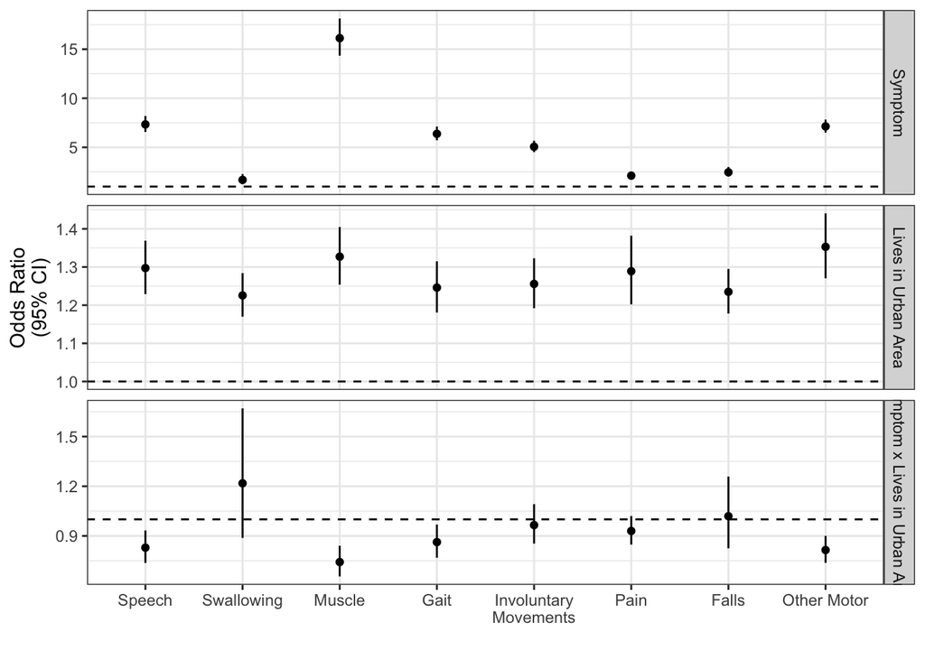

```r
list(
  speech_unadjusted,
  swallowing_unadjusted,
  strength_unadjusted,
  gait_unadjusted,
  involuntary_movements_unadjusted,
  pain_unadjusted,
  falls_unadjusted,
  other_unadjusted
) |>
  lapply(
    broom::tidy,
    exponentiate = TRUE,
    conf.int = TRUE
  ) |>
  enframe() |>
  mutate(
    symptom = c("Speech", "Swallowing", "Muscle",
                "Gait", "Involuntary\nMovements", "Pain", "Falls",
                "Other Motor")
  ) |>
  unnest(cols = value) |>
  mutate(
    variable = rep(c("Symptom", "Lives in Urban Area", "Symptom x Lives in Urban Area"), 8)
  ) |>
  mutate(
    symptom = forcats::fct_relevel(
      symptom,
      "Speech", "Swallowing", "Muscle",
      "Gait", "Involuntary\nMovements", "Pain", "Falls",
      "Other Motor"
    ),
    variable = forcats::fct_relevel(
      variable,
      "Symptom", "Lives in Urban Area", "Symptom x Lives in Urban Area"
    )
  ) |>
  ggplot(
    aes(
      x = symptom,
      y = estimate,
      ymin = conf.low,
      ymax = conf.high
    )
  ) +
  geom_point() +
  geom_linerange() +
  facet_grid(rows = vars(variable), scale = "free_y") +
  geom_hline(yintercept = 1, linetype = 2) +
  labs(x = "", y = "Odds Ratio\n(95% CI)") +
  theme_bw()
```

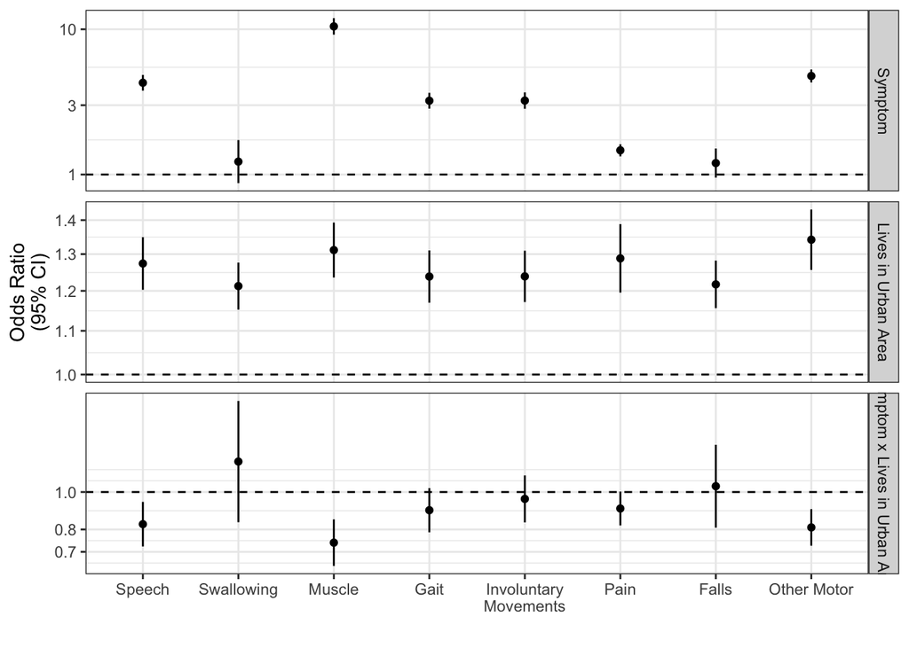

```r
list(
  speech_adjusted,
  swallowing_adjusted,
  strength_adjusted,
  gait_adjusted,
  involuntary_movements_adjusted,
  pain_adjusted,
  falls_adjusted,
  other_adjusted
) |>
  lapply(
    broom::tidy,
    exponentiate = TRUE,
    conf.int = TRUE
  ) |>
  enframe() |>
  mutate(
    symptom = c("Speech", "Swallowing", "Muscle",
                "Gait", "Involuntary\nMovements", "Pain", "Falls",
                "Other Motor")
  ) |>
  unnest(cols = value) |>
  group_by(symptom) |>
  filter(row_number() >= 35) |>
  ungroup() |>
  mutate(
    variable = rep(c("Symptom", "Lives in Urban Area", "Symptom x Lives in Urban Area"), 8)
  ) |>
  mutate(
    symptom = forcats::fct_relevel(
      symptom,
      "Speech", "Swallowing", "Muscle",
      "Gait", "Involuntary\nMovements", "Pain", "Falls",
      "Other Motor"
    ),
    variable = forcats::fct_relevel(
      variable,
      "Symptom", "Lives in Urban Area", "Symptom x Lives in Urban Area"
    )
  ) |>
  ggplot(
    aes(
      x = symptom,
      y = estimate,
      ymin = conf.low,
      ymax = conf.high
    )
  ) +
  geom_point() +
  geom_linerange() +
  facet_grid(rows = vars(variable), scale = "free_y") +
  geom_hline(yintercept = 1, linetype = 2) +
  labs(x = "", y = "Odds Ratio\n(95% CI)") +
  theme_bw() +
  scale_y_log10()
```

```r
ggsave("~/projects/als-sx/fig_1.svg", width = 8, height = 8)
```

### Number of Symptoms

```r
n_symptoms_unadjusted <- clogit(
  number_fml_unadj,
  model_data
)

n_symptoms_unadjusted |>
  broom::tidy(exponentiate = TRUE, conf.int = TRUE) |>
  select(term, estimate, conf.low, conf.high) |>
  knitr::kable(digits = 2)
```

| term | estimate | conf.low | conf.high |
| --- | --- | --- | --- |
| as.factor(n_total)1 | 3.00 | 2.61 | 3.46 |
| as.factor(n_total)2 | 9.61 | 8.27 | 11.17 |
| as.factor(n_total)3 | 21.46 | 18.27 | 25.22 |
| as.factor(n_total)4 | 42.06 | 34.82 | 50.80 |
| as.factor(n_total)5 | 66.20 | 50.74 | 86.37 |
| as.factor(n_total)6 | 57.26 | 39.58 | 82.82 |
| as.factor(n_total)7 | 43.86 | 22.42 | 85.83 |
| as.factor(n_total)8 | 26.13 | 8.41 | 81.21 |
| lives_in_msaTRUE | 1.47 | 1.31 | 1.64 |
| as.factor(n_total)1:lives_in_msaTRUE | 0.98 | 0.84 | 1.14 |
| as.factor(n_total)2:lives_in_msaTRUE | 0.80 | 0.68 | 0.94 |
| as.factor(n_total)3:lives_in_msaTRUE | 0.76 | 0.64 | 0.90 |
| as.factor(n_total)4:lives_in_msaTRUE | 0.71 | 0.58 | 0.87 |
| as.factor(n_total)5:lives_in_msaTRUE | 0.62 | 0.47 | 0.82 |
| as.factor(n_total)6:lives_in_msaTRUE | 0.77 | 0.52 | 1.15 |
| as.factor(n_total)7:lives_in_msaTRUE | 1.10 | 0.54 | 2.26 |
| as.factor(n_total)8:lives_in_msaTRUE | NA | NA | NA |

```r
n_symptoms_adjusted <- clogit(
  number_fml_fulladj,
  model_data
)

n_symptoms_adjusted |>
  broom::tidy(exponentiate = TRUE, conf.int = TRUE) |>
  select(term, estimate, conf.low, conf.high) |>
  knitr::kable(digits = 2)
```

| term | estimate | conf.low | conf.high |
| --- | --- | --- | --- |
| rate_outpatient_visits | 1.02 | 1.01 | 1.02 |
| intensity_outpatient_visits_dx | 1.06 | 1.02 | 1.10 |
| rate_inpatient_stays | 0.79 | 0.74 | 0.84 |
| intensity_inpatient_stays_los | 0.99 | 0.99 | 1.00 |
| elix_CHFTRUE | 0.64 | 0.59 | 0.69 |
| elix_ValvularTRUE | 0.96 | 0.90 | 1.02 |
| elix_PHTNTRUE | 0.99 | 0.89 | 1.09 |
| elix_PVDTRUE | 0.84 | 0.79 | 0.89 |
| elix_HTNTRUE | 0.98 | 0.94 | 1.03 |
| elix_HTNcxTRUE | 0.90 | 0.84 | 0.96 |
| elix_ParalysisTRUE | 2.21 | 2.04 | 2.39 |
| elix_NeuroOtherTRUE | 4.14 | 3.94 | 4.34 |
| elix_PulmonaryTRUE | 0.94 | 0.90 | 0.99 |
| elix_DMTRUE | 0.89 | 0.84 | 0.94 |
| elix_DMcxTRUE | 0.77 | 0.71 | 0.84 |
| elix_HypothyroidTRUE | 1.09 | 1.03 | 1.15 |
| elix_RenalTRUE | 0.61 | 0.56 | 0.67 |
| elix_LiverTRUE | 0.93 | 0.85 | 1.01 |
| elix_PUDTRUE | 0.98 | 0.77 | 1.25 |
| elix_HIVTRUE | 1.13 | 0.78 | 1.66 |
| elix_LymphomaTRUE | 1.24 | 1.08 | 1.43 |
| elix_MetsTRUE | 0.35 | 0.30 | 0.40 |
| elix_TumorTRUE | 0.87 | 0.82 | 0.93 |
| elix_RheumaticTRUE | 1.11 | 1.03 | 1.18 |
| elix_CoagulopathyTRUE | 0.84 | 0.77 | 0.92 |
| elix_ObesityTRUE | 0.78 | 0.73 | 0.83 |
| elix_WeightLossTRUE | 1.55 | 1.45 | 1.66 |
| elix_FluidsLytesTRUE | 0.74 | 0.70 | 0.79 |
| elix_BloodLossTRUE | 0.67 | 0.58 | 0.76 |
| elix_AnemiaTRUE | 1.02 | 0.96 | 1.07 |
| elix_AlcoholTRUE | 0.86 | 0.76 | 0.98 |
| elix_DrugsTRUE | 0.80 | 0.69 | 0.92 |
| elix_PsychosesTRUE | 0.80 | 0.75 | 0.85 |
| elix_DepressionTRUE | 0.90 | 0.85 | 0.95 |
| as.factor(n_total)1 | 2.63 | 2.28 | 3.04 |
| as.factor(n_total)2 | 7.42 | 6.35 | 8.68 |
| as.factor(n_total)3 | 15.17 | 12.79 | 17.99 |
| as.factor(n_total)4 | 26.65 | 21.72 | 32.70 |
| as.factor(n_total)5 | 33.20 | 24.80 | 44.44 |
| as.factor(n_total)6 | 22.63 | 14.96 | 34.23 |
| as.factor(n_total)7 | 16.36 | 7.78 | 34.41 |
| as.factor(n_total)8 | 7.66 | 2.29 | 25.58 |
| lives_in_msaTRUE | 1.46 | 1.30 | 1.63 |
| as.factor(n_total)1:lives_in_msaTRUE | 0.97 | 0.84 | 1.14 |
| as.factor(n_total)2:lives_in_msaTRUE | 0.79 | 0.67 | 0.93 |
| as.factor(n_total)3:lives_in_msaTRUE | 0.75 | 0.63 | 0.90 |
| as.factor(n_total)4:lives_in_msaTRUE | 0.73 | 0.59 | 0.91 |
| as.factor(n_total)5:lives_in_msaTRUE | 0.67 | 0.49 | 0.90 |
| as.factor(n_total)6:lives_in_msaTRUE | 0.91 | 0.58 | 1.40 |
| as.factor(n_total)7:lives_in_msaTRUE | 1.38 | 0.62 | 3.06 |
| as.factor(n_total)8:lives_in_msaTRUE | NA | NA | NA |

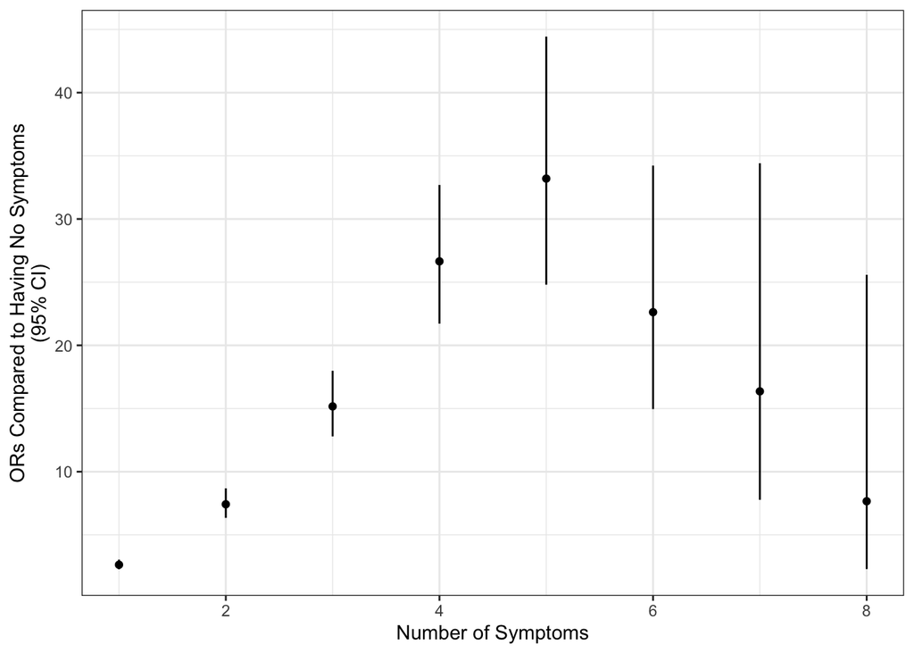

```r
n_symptoms_adjusted |>
  broom::tidy(exponentiate = TRUE, conf.int = TRUE) |>
  filter(!stringr::str_detect(term, "msa"), stringr::str_detect(term, "as.factor")) |>
  mutate(
    variable = 1:8
  ) |>
  ggplot(aes(x = variable,
             y = estimate,
             ymin = conf.low,
             ymax = conf.high)) +
  geom_point() +
  geom_linerange() +
  labs(x = "Number of Symptoms", y = "ORs Compared to Having No Symptoms\n(95% CI)") +
  theme_bw()
```

## Excluding Recent “Exposures”

First, a couple specific models:

```r
delay_30 <- clogit(
  any_fml_fulladj,
  model_data |>
    filter(is.na(first_symptom_date) | (first_symptom_date < (end_date - 30))) |>
    filter(first_date < (end_date - 30)) |>
    mutate(
      across(
        is_logical,
        as.numeric
      )
    )
  )
delay_60 <- clogit(
  any_fml_fulladj,
  model_data |>
    filter(is.na(first_symptom_date) | (first_symptom_date < (end_date - 60))) |>
    filter(first_date < (end_date - 60)) |>
    mutate(
      across(
        is_logical,
        as.numeric
      )
    )
  )

delay_90 <- clogit(
  any_fml_fulladj,
  model_data |>
    filter(is.na(first_symptom_date) | (first_symptom_date < (end_date - 90))) |>
    filter(first_date < (end_date - 90)) |>
    mutate(
      across(
        is_logical,
        as.numeric
      )
    )
  )

delay_180 <- clogit(
  any_fml_fulladj,
  model_data |>
    filter(is.na(first_symptom_date) | (first_symptom_date < (end_date - 180))) |>
    filter(first_date < (end_date - 180)) |>
    mutate(
      across(
        is_logical,
        as.numeric
      )
    )
  )

delay_365 <- clogit(
  any_fml_fulladj,
  model_data |>
    filter(is.na(first_symptom_date) | (first_symptom_date < (end_date - 365))) |>
    filter(first_date < (end_date - 365)) |>
    mutate(
      across(
        is_logical,
        as.numeric
      )
    )
  )

glance_vars <- c("nobs","nevent", "concordance", "r.squared")
tbl_merge(
  tbls = list(
    tbl_regression(delay_30, exponentiate = TRUE) |> add_glance_table(glance_vars),
    tbl_regression(delay_60, exponentiate = TRUE) |> add_glance_table(glance_vars),
    tbl_regression(delay_90, exponentiate = TRUE) |> add_glance_table(glance_vars),
    tbl_regression(delay_180, exponentiate = TRUE) |> add_glance_table(glance_vars),
    tbl_regression(delay_365, exponentiate = TRUE) |> add_glance_table(glance_vars)
  ),
  tab_spanner = c("**30 Day Delay**", "**60 Day Delay**", "**90 Day Delay**",
                  "**180 Day Delay**", "**365 Day Delay**")
) |>
  modify_column_hide(columns = c(p.value_1, p.value_2, p.value_3, p.value_4))
```

| **Characteristic** | **30 Day Delay** **OR**<sup>1</sup> | **30 Day Delay** **95% CI**<sup>1</sup> | **60 Day Delay** **OR**<sup>1</sup> | **60 Day Delay** **95% CI**<sup>1</sup> | **90 Day Delay** **OR**<sup>1</sup> | **90 Day Delay** **95% CI**<sup>1</sup> | **180 Day Delay** **OR**<sup>1</sup> | **180 Day Delay** **95% CI**<sup>1</sup> | **365 Day Delay** **OR**<sup>1</sup> | **365 Day Delay** **95% CI**<sup>1</sup> | **365 Day Delay** **p-value** |
| --- | --- | --- | --- | --- | --- | --- | --- | --- | --- | --- | --- |
| rate_outpatient_visits | 1.02 | 1.02, 1.03 | 1.03 | 1.02, 1.03 | 1.03 | 1.03, 1.03 | 1.03 | 1.03, 1.03 | 1.03 | 1.03, 1.03 | <0.001 |
| intensity_outpatient_visits_dx | 1.14 | 1.09, 1.18 | 1.14 | 1.10, 1.19 | 1.14 | 1.10, 1.19 | 1.13 | 1.08, 1.17 | 1.11 | 1.06, 1.16 | <0.001 |
| rate_inpatient_stays | 0.78 | 0.74, 0.83 | 0.78 | 0.73, 0.83 | 0.78 | 0.73, 0.83 | 0.78 | 0.73, 0.83 | 0.79 | 0.73, 0.85 | <0.001 |
| intensity_inpatient_stays_los | 1.00 | 0.99, 1.00 | 1.00 | 0.99, 1.00 | 1.00 | 0.99, 1.00 | 1.00 | 0.99, 1.00 | 1.00 | 0.99, 1.01 | >0.9 |
| elix_CHF | 0.63 | 0.59, 0.68 | 0.64 | 0.59, 0.69 | 0.63 | 0.58, 0.68 | 0.63 | 0.58, 0.68 | 0.64 | 0.59, 0.70 | <0.001 |
| elix_Valvular | 0.97 | 0.92, 1.03 | 0.97 | 0.91, 1.02 | 0.97 | 0.92, 1.03 | 0.97 | 0.91, 1.03 | 0.98 | 0.92, 1.04 | 0.5 |
| elix_PHTN | 0.98 | 0.89, 1.09 | 0.98 | 0.89, 1.09 | 0.99 | 0.90, 1.10 | 1.01 | 0.91, 1.12 | 0.98 | 0.88, 1.10 | 0.8 |
| elix_PVD | 0.92 | 0.87, 0.98 | 0.94 | 0.88, 0.99 | 0.94 | 0.88, 1.0 | 0.92 | 0.87, 0.98 | 0.91 | 0.86, 0.98 | 0.008 |
| elix_HTN | 0.99 | 0.95, 1.03 | 1.00 | 0.95, 1.04 | 1.00 | 0.96, 1.05 | 1.01 | 0.97, 1.06 | 1.01 | 0.96, 1.07 | 0.6 |
| elix_HTNcx | 0.91 | 0.85, 0.97 | 0.91 | 0.86, 0.97 | 0.91 | 0.85, 0.97 | 0.91 | 0.85, 0.97 | 0.91 | 0.84, 0.97 | 0.007 |
| elix_Paralysis | 2.99 | 2.77, 3.23 | 2.95 | 2.72, 3.19 | 2.94 | 2.72, 3.19 | 2.93 | 2.70, 3.18 | 2.89 | 2.65, 3.16 | <0.001 |
| elix_NeuroOther | 5.28 | 5.05, 5.53 | 5.33 | 5.09, 5.58 | 5.33 | 5.09, 5.59 | 5.26 | 5.00, 5.52 | 5.09 | 4.83, 5.37 | <0.001 |
| elix_Pulmonary | 0.96 | 0.91, 1.00 | 0.95 | 0.91, 1.00 | 0.96 | 0.91, 1.00 | 0.97 | 0.93, 1.02 | 0.99 | 0.94, 1.04 | 0.8 |
| elix_DM | 0.87 | 0.82, 0.92 | 0.88 | 0.83, 0.93 | 0.89 | 0.84, 0.94 | 0.89 | 0.84, 0.95 | 0.91 | 0.86, 0.97 | 0.004 |
| elix_DMcx | 0.79 | 0.73, 0.86 | 0.79 | 0.73, 0.85 | 0.78 | 0.72, 0.85 | 0.78 | 0.72, 0.85 | 0.77 | 0.70, 0.84 | <0.001 |
| elix_Hypothyroid | 1.11 | 1.05, 1.16 | 1.10 | 1.05, 1.16 | 1.09 | 1.04, 1.15 | 1.09 | 1.03, 1.15 | 1.10 | 1.04, 1.16 | 0.001 |
| elix_Renal | 0.58 | 0.53, 0.64 | 0.58 | 0.53, 0.63 | 0.58 | 0.53, 0.63 | 0.59 | 0.53, 0.65 | 0.58 | 0.53, 0.65 | <0.001 |
| elix_Liver | 0.93 | 0.86, 1.01 | 0.93 | 0.86, 1.01 | 0.94 | 0.86, 1.02 | 0.92 | 0.85, 1.01 | 0.95 | 0.86, 1.04 | 0.2 |
| elix_PUD | 1.01 | 0.80, 1.27 | 1.01 | 0.80, 1.27 | 0.96 | 0.76, 1.21 | 1.00 | 0.79, 1.27 | 0.99 | 0.77, 1.27 | >0.9 |
| elix_HIV | 1.01 | 0.70, 1.45 | 1.02 | 0.71, 1.48 | 1.07 | 0.74, 1.55 | 1.04 | 0.72, 1.52 | 1.07 | 0.72, 1.58 | 0.7 |
| elix_Lymphoma | 1.24 | 1.08, 1.42 | 1.18 | 1.03, 1.36 | 1.19 | 1.03, 1.38 | 1.21 | 1.04, 1.40 | 1.18 | 1.01, 1.38 | 0.033 |
| elix_Mets | 0.33 | 0.29, 0.38 | 0.34 | 0.30, 0.39 | 0.34 | 0.30, 0.39 | 0.35 | 0.31, 0.41 | 0.39 | 0.34, 0.45 | <0.001 |
| elix_Tumor | 0.86 | 0.81, 0.91 | 0.86 | 0.81, 0.92 | 0.88 | 0.82, 0.93 | 0.89 | 0.83, 0.95 | 0.89 | 0.83, 0.95 | <0.001 |
| elix_Rheumatic | 1.25 | 1.17, 1.33 | 1.26 | 1.18, 1.35 | 1.26 | 1.19, 1.35 | 1.26 | 1.18, 1.35 | 1.27 | 1.19, 1.36 | <0.001 |
| elix_Coagulopathy | 0.85 | 0.78, 0.93 | 0.85 | 0.78, 0.93 | 0.85 | 0.78, 0.93 | 0.86 | 0.78, 0.94 | 0.84 | 0.76, 0.92 | <0.001 |
| elix_Obesity | 0.83 | 0.79, 0.89 | 0.85 | 0.80, 0.90 | 0.86 | 0.80, 0.91 | 0.86 | 0.81, 0.92 | 0.87 | 0.81, 0.93 | <0.001 |
| elix_WeightLoss | 1.65 | 1.55, 1.76 | 1.62 | 1.52, 1.73 | 1.63 | 1.52, 1.74 | 1.58 | 1.48, 1.70 | 1.54 | 1.43, 1.66 | <0.001 |
| elix_FluidsLytes | 0.79 | 0.75, 0.84 | 0.80 | 0.76, 0.85 | 0.80 | 0.75, 0.85 | 0.81 | 0.76, 0.86 | 0.81 | 0.76, 0.86 | <0.001 |
| elix_BloodLoss | 0.70 | 0.61, 0.79 | 0.69 | 0.61, 0.79 | 0.70 | 0.62, 0.80 | 0.72 | 0.63, 0.82 | 0.73 | 0.63, 0.83 | <0.001 |
| elix_Anemia | 1.05 | 1.00, 1.11 | 1.06 | 1.00, 1.11 | 1.06 | 1.00, 1.11 | 1.05 | 1.00, 1.11 | 1.06 | 1.00, 1.12 | 0.057 |
| elix_Alcohol | 0.83 | 0.73, 0.93 | 0.83 | 0.74, 0.94 | 0.84 | 0.74, 0.95 | 0.85 | 0.75, 0.97 | 0.85 | 0.74, 0.97 | 0.016 |
| elix_Drugs | 0.82 | 0.71, 0.94 | 0.82 | 0.71, 0.95 | 0.82 | 0.71, 0.95 | 0.82 | 0.71, 0.96 | 0.81 | 0.69, 0.95 | 0.008 |
| elix_Psychoses | 0.82 | 0.77, 0.87 | 0.82 | 0.76, 0.87 | 0.82 | 0.77, 0.88 | 0.83 | 0.78, 0.89 | 0.84 | 0.78, 0.90 | <0.001 |
| elix_Depression | 0.98 | 0.92, 1.03 | 0.98 | 0.93, 1.04 | 0.98 | 0.93, 1.03 | 0.97 | 0.92, 1.03 | 0.98 | 0.93, 1.05 | 0.6 |
| any_sx | 4.49 | 3.97, 5.07 | 4.20 | 3.71, 4.75 | 3.98 | 3.51, 4.50 | 3.56 | 3.14, 4.04 | 3.08 | 2.70, 3.51 | <0.001 |
| lives_in_msa | 1.42 | 1.27, 1.60 | 1.42 | 1.27, 1.59 | 1.42 | 1.26, 1.59 | 1.41 | 1.26, 1.58 | 1.40 | 1.25, 1.58 | <0.001 |
| any_sx * lives_in_msa | 0.83 | 0.73, 0.95 | 0.83 | 0.73, 0.95 | 0.83 | 0.73, 0.95 | 0.84 | 0.73, 0.96 | 0.85 | 0.74, 0.97 | 0.017 |
| No. Obs. | 113,827 |  | 112,410 |  | 111,062 |  | 107,147 |  | 98,850 |  |  |
| N events | 18,342 |  | 17,615 |  | 17,016 |  | 15,574 |  | 13,418 |  |  |
| c-index | 0.795 |  | 0.794 |  | 0.793 |  | 0.789 |  | 0.778 |  |  |
| R² | 0.150 |  | 0.146 |  | 0.142 |  | 0.133 |  | 0.117 |  |  |

<sup>1</sup> OR = Odds Ratio, CI = Confidence Interval

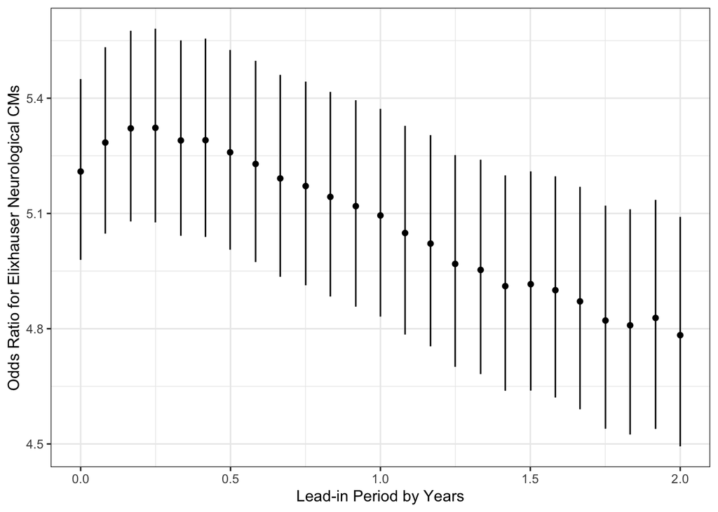

```r
lags <- round(seq(0, 2, by = 1/12) * 365)
results <- vector("list", length(lags))
j <- 1
p <- progress::progress_bar$new(
  total = length(lags),
  format = "[:bar] :percent in :elapsed with :eta remaining"
)
for (i in lags) {
  results[[j]] <- clogit(
    any_fml_fulladj,
    model_data |>
      filter(is.na(first_symptom_date) | (first_symptom_date < (end_date - i))) |>
      filter(first_date < (end_date - i))
    ) |>
      broom::tidy(exponentiate = TRUE, conf.int = TRUE) |>
      mutate(i = i) |>
      select(i, term, estimate, conf.low, conf.high)
    j <- j + 1
    p$tick()
}

results |>
  bind_rows() |>
  filter(
    stringr::str_detect(term, "Neuro")
  ) |>
  ggplot(aes(x = i / 365,
             y = estimate,
             ymin = conf.low,
             ymax = conf.high)) +
  geom_point() +
  geom_linerange() +
  labs(x = "Lead-in Period by Years",
       y = "Odds Ratio for Elixhauser Neurological CMs") +
  theme_bw()
```

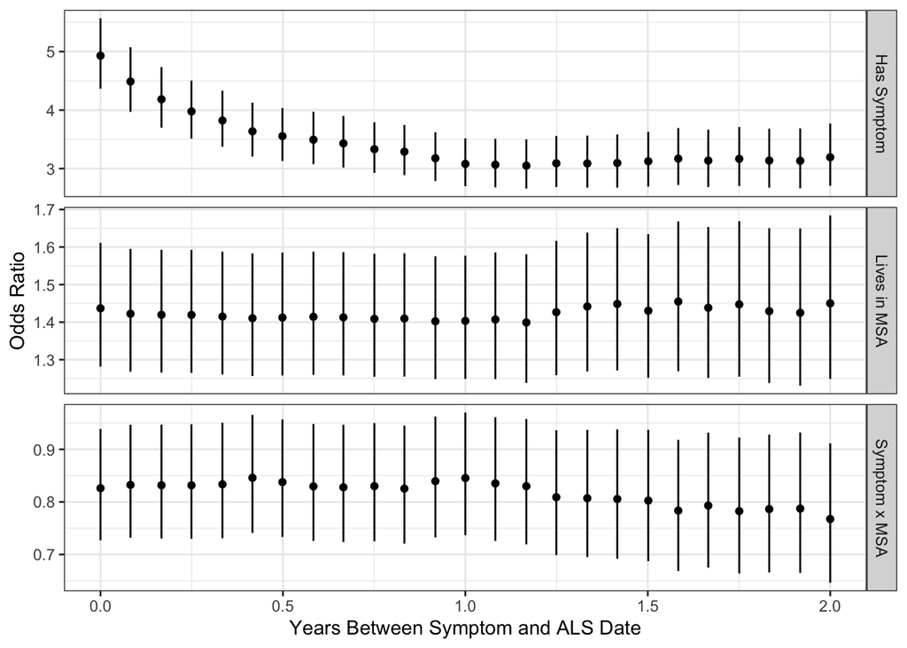

```r
ggsave("~/projects/als-sx/neuro_series.svg", width = 16/2, height = 9/2)

results |>
  bind_rows() |>
  filter(
    stringr::str_detect(term, "sx") | stringr::str_detect(term, "msa")
  ) |>
  mutate(
    term = case_when(
      term == "any_sxTRUE" ~ "Has Symptom",
      term == "lives_in_msaTRUE" ~ "Lives in MSA",
      term == "any_sxTRUE:lives_in_msaTRUE" ~ "Symptom x MSA"
    ),
    term = forcats::fct_relevel(term,
      "Has Symptom", "Lives in MSA")
  ) |>
  ggplot(
    aes(
      x = i / 365,
      y = estimate,
      ymin = conf.low,
      ymax = conf.high
    )
  ) +
  geom_point() +
  geom_linerange() +
  facet_grid(rows = vars(term), scales = "free_y") +
  labs(x = "Years Between Symptom and ALS Date", y = "Odds Ratio") +
  theme_bw()
```

```r
ggsave("~/projects/als-sx/symptom_series.svg", width = 16/2, height = 9/2)
```